# Programa de Pós-graduação em Computação Aplicada – PPCA (UnB)

## Análise Estatística de Dados e Informações - Prova Final

##### Professor: João Gabriel de Moraes Souza

##### Aluno: [Angelo Donizete Buso Júnior](https://tr.ee/On58b8WbPz)

```python
import warnings
warnings.filterwarnings("ignore")

# Manipulação de Dados
import pandas as pd
from IPython.display import display
import numpy as np

# Visualização de Dados
import matplotlib.pyplot as plt
import matplotlib.patches as mpatches
import seaborn as sns

# Estatística e Testes Estatísticos
import shap
from scipy import stats
from scipy.stats import kurtosis, skew, f_oneway, shapiro, levene, kruskal
import statsmodels.api as sm
from statsmodels.formula.api import ols
from statsmodels.stats.outliers_influence import variance_inflation_factor

# Pré-Processamento de Dados
from sklearn.model_selection import KFold, cross_validate
from sklearn.preprocessing import StandardScaler, LabelEncoder, MinMaxScaler, OneHotEncoder
from imblearn.under_sampling import RandomUnderSampler
from imblearn.over_sampling import SMOTE
from collections import Counter

# Algoritmos de Machine Learning
from sklearn.linear_model import LinearRegression, LogisticRegression
from sklearn.svm import SVC

# Treinamento e Validação de Modelos
from sklearn.model_selection import train_test_split, cross_val_score, GridSearchCV, StratifiedKFold

# Avaliação de Modelos
from sklearn.metrics import (
    mean_squared_error, mean_absolute_error, r2_score,
    confusion_matrix, accuracy_score, precision_score, recall_score,
    classification_report, roc_auc_score, roc_curve, ConfusionMatrixDisplay
)
from scikitplot.metrics import plot_confusion_matrix, plot_roc

# Configurações Opcionais
pd.set_option('display.float_format', '{:.2f}'.format)
sns.set_theme(style="whitegrid")
plt.rc("figure", figsize=(10, 6))

# Verificação de Versões
print("Versão do Seaborn:", sns.__version__)
print("Versão do Pandas:", pd.__version__)
```

```
Versão do Seaborn: 0.13.2
Versão do Pandas: 2.2.3
```

# Questão 2

## 1. Compreensão do Problema de Negócio

No setor hoteleiro, compreender os fatores que levam ao cancelamento de reservas é essencial para otimizar a gestão de ocupação e maximizar a receita. Cancelamentos inesperados podem resultar em quartos vagos, impactando negativamente a rentabilidade dos hotéis. A aplicação de modelos preditivos permite antecipar o comportamento dos clientes, possibilitando a implementação de estratégias proativas para mitigar os efeitos dos cancelamentos.

Neste estudo, focaremos na previsão de cancelamentos de reservas utilizando o conjunto de dados Hotel Booking Demand, disponível no [Kaggle](https://www.kaggle.com/datasets/jessemostipak/hotel-booking-demand/data). Este dataset compreende informações sobre reservas em dois tipos de hotéis: um hotel urbano e um resort.

Para prever a probabilidade de cancelamento de uma reserva, utilizaremos a Regressão Logística, uma técnica estatística adequada para modelar desfechos binários, como cancelado ou não cancelado. Além disso, aplicaremos a metodologia CRISP-DM (Cross-Industry Standard Process for Data Mining) para estruturar nossa análise, garantindo uma abordagem sistemática e eficaz.

Este estudo visa não apenas construir um modelo preditivo, mas também identificar e interpretar as variáveis que mais influenciam o cancelamento de reservas. Compreender esses fatores permitirá aos gestores hoteleiros desenvolver estratégias direcionadas para reduzir os cancelamentos e melhorar a eficiência operacional.

### **1.1 Dicionário de Dados**

#### Informações sobre os atributos:

| Nome da Coluna | Descrição |
| --- | --- |
| hotel | Tipo de hotel (Resort Hotel ou City Hotel) |
| is_canceled **variável target** | Indica se a reserva foi cancelada (1) ou não (0) |
| lead_time | Número de dias entre a data de inserção da reserva no sistema e a data de chegada |
| arrival_date_year | Ano da data de chegada |
| arrival_date_month | Mês da data de chegada |
| arrival_date_week_number | Número da semana do ano referente à data de chegada |
| arrival_date_day_of_month | Dia do mês da data de chegada |
| stays_in_weekend_nights | Número de noites de fim de semana (sábado ou domingo) que o hóspede permaneceu ou reservou para permanecer no hotel |
| stays_in_week_nights | Número de noites de semana (segunda a sexta-feira) que o hóspede permaneceu ou reservou para permanecer no hotel |
| adults | Número de adultos |
| children | Número de crianças |
| babies | Número de bebês |
| meal | Tipo de refeição reservada. Categorias: BB (Bed & Breakfast), HB (Half board - café da manhã e uma outra refeição), FB (Full board - café da manhã, almoço e jantar), SC (Self Catering - sem pacote de … |
| country | País de origem, representado no formato ISO 3155–3:2013 |
| market_segment | Segmento de mercado da reserva. Por exemplo, TA (Travel Agents) ou TO (Tour Operators) |
| distribution_channel | Canal de distribuição da reserva. Por exemplo, TA (Travel Agents) ou TO (Tour Operators) |
| is_repeated_guest | Indica se o hóspede é repetido (1) ou não (0) |
| previous_cancellations | Número de reservas anteriores que foram canceladas pelo cliente antes da reserva atual |
| previous_bookings_not_canceled | Número de reservas anteriores não canceladas pelo cliente antes da reserva atual |
| reserved_room_type | Código do tipo de quarto reservado |
| assigned_room_type | Código do tipo de quarto atribuído à reserva |
| booking_changes | Número de alterações feitas na reserva desde a inserção no sistema até o momento do check-in ou cancelamento |
| deposit_type | Indicação se o cliente fez um depósito para garantir a reserva. Categorias: No Deposit (nenhum depósito), Non Refund (depósito no valor total da estadia), Refundable (depósito com valor inferior ao cu… |
| agent | ID da agência de viagens que fez a reserva |
| company | ID da empresa responsável pela reserva ou pagamento |
| days_in_waiting_list | Número de dias que a reserva ficou na lista de espera antes de ser confirmada para o cliente |
| customer_type | Tipo de cliente: Contract (contrato), Group (grupo), Transient (transitório), Transient-party (transitório com outros) |
| adr | Taxa Média Diária, calculada dividindo a soma de todas as transações de hospedagem pelo número total de noites de estadia |
| required_car_parking_spaces | Número de vagas de estacionamento requeridas pelo cliente |
| total_of_special_requests | Número de pedidos especiais feitos pelo cliente (por exemplo, cama de solteiro ou andar alto) |
| reservation_status | Status final da reserva: Canceled (cancelada), Check-Out (cliente fez check-in e já saiu), No-Show (cliente não fez check-in e não informou o motivo) |
| reservation_status_date | Data em que o último status foi definido |

## 2. Coleta de Dados

Para este projeto de *machine learning*, utilizaremos o conjunto de dados **Hotel Booking Demand**, disponível no [Kaggle](https://www.kaggle.com/datasets/jessemostipak/hotel-booking-demand/data).

Este dataset abrange informações detalhadas sobre reservas em dois tipos de hotéis: **City Hotel** e **Resort Hotel**. As variáveis presentes podem ser classificadas nas seguintes categorias:

- **Informações sobre a reserva**:
  - `is_canceled`: Indica se a reserva foi cancelada ou não.
  - `lead_time`: Número de dias entre a data da reserva e a data de chegada.
  - `arrival_date_year`, `arrival_date_month`, `arrival_date_week_number`, `arrival_date_day_of_month`: Detalhes sobre a data de chegada.
  - `stays_in_weekend_nights`, `stays_in_week_nights`: Número de noites de estadia durante fins de semana e dias da semana.
- **Informações sobre os hóspedes**:
  - `adults`, `children`, `babies`: Número de adultos, crianças e bebês na reserva.
  - `country`: País de origem do hóspede.
  - `is_repeated_guest`: Indica se o hóspede é recorrente.
- **Informações sobre a estadia**:
  - `reserved_room_type`, `assigned_room_type`: Tipo de quarto reservado e tipo de quarto atribuído.
  - `booking_changes`: Número de alterações feitas na reserva.
  - `deposit_type`: Tipo de depósito associado à reserva.
  - `agent`, `company`: IDs da agência de viagens e da empresa associada à reserva.
  - `days_in_waiting_list`: Número de dias que a reserva ficou na lista de espera.
  - `customer_type`: Tipo de cliente (e.g., contrato, grupo, transiente).
- **Informações financeiras**:
  - `adr`: Taxa média diária aplicada à reserva.
  - `required_car_parking_spaces`: Número de vagas de estacionamento requeridas.
  - `total_of_special_requests`: Número de pedidos especiais feitos pelo hóspede.

Essas informações nos permitirão identificar padrões e fatores que influenciam o cancelamento de reservas, auxiliando na construção de um modelo preditivo eficaz.

**Dicas:**

1. Observar as extensão do arquivo dataSet.
2. Verificar os acessos aos dataSet (LGPD).
3. "Timeframe" dos dados (desde quando tem-se os dados).
4. Valores Missing (será substituido por default ou outro valor - média, por exemplo).
5. Cabeçalho (header=T), caso False, irá indicar cabeçalho.
6. Dados possuem algum comentário.
7. Possui delimitador os dados.

### **2.1 Carga dados**

**Dicas:**

(i) Observar as extensão do arquivo dataSet;

(ii) Verificar os acessos aos dataSet;

(iii) "Timeframe" dos dados (desde quando tem-se os dados);

(iv) Valores Missing (será substituido por default ou outro valor - média, por exemplo);

(v) Cabeçalho (header=T), caso False, irá indicar cabeçalho;

(vi) Dados possuem algum comentário;

(vii) Possui delimitador os dados;

(viii) Até 3 dimensões PANDAS (1Series, 2DataFrame e 3Panel). Acima 3 dim NUMPY (nparray).

```python
path = "/home/buso/mestrado/aedi-ppca/dados/hotel_bookings.csv"
df = pd.read_csv(path)
print('Os dados possuem {} linhas e {} colunas'.format(df.shape[0], df.shape[1]))
df.head()
```

```
Os dados possuem 119390 linhas e 32 colunas
```

|  | hotel | is_canceled | lead_time | arrival_date_year | arrival_date_month | arrival_date_week_number | arrival_date_day_of_month | stays_in_weekend_nights | stays_in_week_nights | adults | ... | deposit_type | agent | company | days_in_waiting_list | customer_type | adr | required_car_parking_spaces | total_of_special_requests | reservation_status | reservation_status_date |
| --- | --- | --- | --- | --- | --- | --- | --- | --- | --- | --- | --- | --- | --- | --- | --- | --- | --- | --- | --- | --- | --- |
| 0 | Resort Hotel | 0 | 342 | 2015 | July | 27 | 1 | 0 | 0 | 2 | ... | No Deposit | NaN | NaN | 0 | Transient | 0.0 | 0 | 0 | Check-Out | 2015-07-01 |
| 1 | Resort Hotel | 0 | 737 | 2015 | July | 27 | 1 | 0 | 0 | 2 | ... | No Deposit | NaN | NaN | 0 | Transient | 0.0 | 0 | 0 | Check-Out | 2015-07-01 |
| 2 | Resort Hotel | 0 | 7 | 2015 | July | 27 | 1 | 0 | 1 | 1 | ... | No Deposit | NaN | NaN | 0 | Transient | 75.0 | 0 | 0 | Check-Out | 2015-07-02 |
| 3 | Resort Hotel | 0 | 13 | 2015 | July | 27 | 1 | 0 | 1 | 1 | ... | No Deposit | 304.0 | NaN | 0 | Transient | 75.0 | 0 | 0 | Check-Out | 2015-07-02 |
| 4 | Resort Hotel | 0 | 14 | 2015 | July | 27 | 1 | 0 | 2 | 2 | ... | No Deposit | 240.0 | NaN | 0 | Transient | 98.0 | 0 | 1 | Check-Out | 2015-07-03 |

5 rows × 32 columns

## 3. Análise Exploratória

### 3.1 Visão Geral dataSet

Nesta estapa estamos interessados em entender melhor a pergunta **"Quais tipos de dados tem no nosso dataSet?"**

- Tipo Objeto que estamos trabalhando
- Tipos Dados
- Shape - Dimensionalidade
- Índices
- Descrição dos dados

```python
def visaogeral(df, mensagem):
    print(f'{mensagem}:\n')
    print("Qtd Observações:", df.shape[0])
    print("\nQtd Atributos:", df.shape[1])
    print("\nAtributos:")
    print(df.columns.values)
    # print(df.columns.tolist())
    print("\nQtd Valores missing:", df.isnull().sum().values.sum())
    print("\nValores Unicos:")
    print(df.nunique().sort_values(ascending=True))
```

```python
visaogeral(df,'Visão Geral do dataSet')
```

```
Visão Geral do dataSet:

Qtd Observações: 119390

Qtd Atributos: 32

Atributos:
['hotel' 'is_canceled' 'lead_time' 'arrival_date_year'
 'arrival_date_month' 'arrival_date_week_number'
 'arrival_date_day_of_month' 'stays_in_weekend_nights'
 'stays_in_week_nights' 'adults' 'children' 'babies' 'meal' 'country'
 'market_segment' 'distribution_channel' 'is_repeated_guest'
 'previous_cancellations' 'previous_bookings_not_canceled'
 'reserved_room_type' 'assigned_room_type' 'booking_changes'
 'deposit_type' 'agent' 'company' 'days_in_waiting_list' 'customer_type'
 'adr' 'required_car_parking_spaces' 'total_of_special_requests'
 'reservation_status' 'reservation_status_date']

Qtd Valores missing: 129425

Valores Unicos:
hotel                                2
is_canceled                          2
is_repeated_guest                    2
arrival_date_year                    3
deposit_type                         3
reservation_status                   3
customer_type                        4
required_car_parking_spaces          5
meal                                 5
babies                               5
distribution_channel                 5
children                             5
total_of_special_requests            6
market_segment                       8
reserved_room_type                  10
arrival_date_month                  12
assigned_room_type                  12
adults                              14
previous_cancellations              15
stays_in_weekend_nights             17
booking_changes                     21
arrival_date_day_of_month           31
stays_in_week_nights                35
arrival_date_week_number            53
previous_bookings_not_canceled      73
days_in_waiting_list               128
country                            177
agent                              333
company                            352
lead_time                          479
reservation_status_date            926
adr                               8879
dtype: int64
```

O conjunto de dados possui aproximadamente cerca de **120 mil observações** e **32 atributos**, podemos observar a presença de valores ausentes (*missing*). Os atributos incluem característica e informações sobre a reserva, os hóspedes, a estadia escolhida e valores pagos nas estadias. Abaixo, destacamos os atributos categóricos e quantitativos:

- **Atributos categóricos**: a princípio as features elencadas abaixo podem representar categorias:
  - `hotel`, `is_canceled`, `is_repeated_guest`, `deposit_type`, `reservation_status`, `customer_type`, `required_car_parking_spaces`, `meal`, `distribution_channel`, `total_of_special_requests`, `market_segment`, `reserved_room_type`, `assigned_room_type`, `country`.
- **Atributos quantitativos**: as demais, *a priori* demonstra ser *features* numéricas e contínuas, sendo que após o processo de exploração dos dados (EDA) seja interessante realizar algumas trasformaões em categórias nelas.

Nosso objetivo é realmente entender se esses formatos representam a **informação** que a *feature* precisa passar!

Essa combinação de atributos categóricos e quantitativos é fundamental para capturar os diferentes fatores que influenciam a probabilidade de cancelamento dos hóspedes.

```python
df.info()
```

```
<class 'pandas.core.frame.DataFrame'>
RangeIndex: 119390 entries, 0 to 119389
Data columns (total 32 columns):
 #   Column                          Non-Null Count   Dtype
---  ------                          --------------   -----
 0   hotel                           119390 non-null  object
 1   is_canceled                     119390 non-null  int64
 2   lead_time                       119390 non-null  int64
 3   arrival_date_year               119390 non-null  int64
 4   arrival_date_month              119390 non-null  object
 5   arrival_date_week_number        119390 non-null  int64
 6   arrival_date_day_of_month       119390 non-null  int64
 7   stays_in_weekend_nights         119390 non-null  int64
 8   stays_in_week_nights            119390 non-null  int64
 9   adults                          119390 non-null  int64
```

[output cut: 24 more lines]

A análise exploratória realizada proporcionou uma **compreensão inicial** sobre a estrutura e qualidade do conjunto de dados. O dataset contém aproximadamente **120 mil registros** de reservas em hotéis, detalhando informações sobre os clientes e se as reservas foram canceladas ou não.

A inspeção das variáveis revelou a presença de **atributos categóricos**, exigindo a aplicação de técnicas de **codificação de variáveis**, como **One-Hot Encoding**, para possibilitar sua utilização em modelos de *Machine Learning* baseados em algoritmos que requerem representações numéricas.

Outro ponto relevante é a identificação de **valores ausentes** em algumas variáveis, o que demanda um tratamento adequado. Além disso, durante o processo de **engenharia de atributos** (*feature engineering*) e **transformação de variáveis**, podem surgir valores nulos em decorrência de operações como discretização, normalização ou derivação de novas variáveis. Assim, será essencial **monitorar, imputar e tratar** esses valores para garantir a **qualidade e integridade dos dados**, assegurando que o modelo preditivo alcance um desempenho confiável.

**TRADE-OFFs da Ciência de Dados e o Dilema Viés-Variância**

No desenvolvimento de modelos de *Machine Learning*, é fundamental equilibrar **quantidade de dados**, **dimensionalidade** e **tempo de treinamento**, garantindo um modelo eficiente e generalizável. Esse processo envolve decisões estratégicas para evitar problemas como **underfitting** e **overfitting**, além de considerar o **dilema viés-variância**.

**Tamanho do Conjunto de Dados**

Se o número de **observações** no conjunto de dados for **muito grande**, o treinamento pode ser **computacionalmente custoso**, exigindo técnicas como **amostragem representativa**, **processamento distribuído** (ex.: Spark, Dask) ou **redução de dimensionalidade** (ex.: PCA). Por outro lado, um número **muito pequeno** de registros pode levar ao **underfitting**, onde o modelo não consegue capturar padrões relevantes e apresenta baixa capacidade preditiva.

**Dimensionalidade e Seleção de Features**

Muitas **colunas/atributos** podem gerar problemas de **alta dimensionalidade**, dificultando a modelagem e aumentando o risco de **overfitting**, quando o modelo se ajusta excessivamente aos dados de treino e perde **capacidade de generalização**. Para mitigar esse problema, técnicas como **seleção de variáveis** (ex.: *feature selection*) e **redução de dimensionalidade** (ex.: PCA, *Autoencoders*) são recomendadas.

**O Dilema Viés-Variância**

O dilema **viés-variância** descreve o equilíbrio entre **simplicidade** e **complexidade** do modelo:

- **Viés alto (underfitting)**: O modelo é muito simples e não captura os padrões dos dados adequadamente, erra muito ou tudo.
- **Variância alta (overfitting)**: O modelo é muito complexo e se ajusta excessivamente aos dados de treino, resultando em baixa generalização.

A solução ideal envolve encontrar um meio-termo, onde o modelo **aprende bem os padrões dos dados sem se tornar excessivamente específico**.

**Divisão de Dados e Validação**

A prática recomendada é dividir o conjunto de dados em:

- **Treino (70%)**: Para ensinar o modelo.
- **Teste (30%)**: Para avaliar a performance em dados novos.
- **Validação cruzada**: Para evitar dependência de uma única divisão dos dados e garantir que o modelo tenha **boa generalização**.

**E então?**

Não existe uma solução única para esses desafios, e cada problema exige um equilíbrio entre **quantidade de dados**, **dimensionalidade**, **tempo de treinamento** e **capacidade de generalização**. Estratégias como **seleção de variáveis, validação cruzada e ajuste de hiperparâmetros** são essenciais para otimizar o modelo e garantir **desempenho robusto e confiável**.

Observando uma amostra inicial e uma amostra final do dataSet.

```python
df.head()
```

|  | hotel | is_canceled | lead_time | arrival_date_year | arrival_date_month | arrival_date_week_number | arrival_date_day_of_month | stays_in_weekend_nights | stays_in_week_nights | adults | ... | deposit_type | agent | company | days_in_waiting_list | customer_type | adr | required_car_parking_spaces | total_of_special_requests | reservation_status | reservation_status_date |
| --- | --- | --- | --- | --- | --- | --- | --- | --- | --- | --- | --- | --- | --- | --- | --- | --- | --- | --- | --- | --- | --- |
| 0 | Resort Hotel | 0 | 342 | 2015 | July | 27 | 1 | 0 | 0 | 2 | ... | No Deposit | NaN | NaN | 0 | Transient | 0.0 | 0 | 0 | Check-Out | 2015-07-01 |
| 1 | Resort Hotel | 0 | 737 | 2015 | July | 27 | 1 | 0 | 0 | 2 | ... | No Deposit | NaN | NaN | 0 | Transient | 0.0 | 0 | 0 | Check-Out | 2015-07-01 |
| 2 | Resort Hotel | 0 | 7 | 2015 | July | 27 | 1 | 0 | 1 | 1 | ... | No Deposit | NaN | NaN | 0 | Transient | 75.0 | 0 | 0 | Check-Out | 2015-07-02 |
| 3 | Resort Hotel | 0 | 13 | 2015 | July | 27 | 1 | 0 | 1 | 1 | ... | No Deposit | 304.0 | NaN | 0 | Transient | 75.0 | 0 | 0 | Check-Out | 2015-07-02 |
| 4 | Resort Hotel | 0 | 14 | 2015 | July | 27 | 1 | 0 | 2 | 2 | ... | No Deposit | 240.0 | NaN | 0 | Transient | 98.0 | 0 | 1 | Check-Out | 2015-07-03 |

5 rows × 32 columns

```python
df.tail()
```

|  | hotel | is_canceled | lead_time | arrival_date_year | arrival_date_month | arrival_date_week_number | arrival_date_day_of_month | stays_in_weekend_nights | stays_in_week_nights | adults | ... | deposit_type | agent | company | days_in_waiting_list | customer_type | adr | required_car_parking_spaces | total_of_special_requests | reservation_status | reservation_status_date |
| --- | --- | --- | --- | --- | --- | --- | --- | --- | --- | --- | --- | --- | --- | --- | --- | --- | --- | --- | --- | --- | --- |
| 119385 | City Hotel | 0 | 23 | 2017 | August | 35 | 30 | 2 | 5 | 2 | ... | No Deposit | 394.0 | NaN | 0 | Transient | 96.14 | 0 | 0 | Check-Out | 2017-09-06 |
| 119386 | City Hotel | 0 | 102 | 2017 | August | 35 | 31 | 2 | 5 | 3 | ... | No Deposit | 9.0 | NaN | 0 | Transient | 225.43 | 0 | 2 | Check-Out | 2017-09-07 |
| 119387 | City Hotel | 0 | 34 | 2017 | August | 35 | 31 | 2 | 5 | 2 | ... | No Deposit | 9.0 | NaN | 0 | Transient | 157.71 | 0 | 4 | Check-Out | 2017-09-07 |
| 119388 | City Hotel | 0 | 109 | 2017 | August | 35 | 31 | 2 | 5 | 2 | ... | No Deposit | 89.0 | NaN | 0 | Transient | 104.40 | 0 | 0 | Check-Out | 2017-09-07 |
| 119389 | City Hotel | 0 | 205 | 2017 | August | 35 | 29 | 2 | 7 | 2 | ... | No Deposit | 9.0 | NaN | 0 | Transient | 151.20 | 0 | 2 | Check-Out | 2017-09-07 |

5 rows × 32 columns

Relembrando o shape dos dados:

```python
print('Os dados possuem {:.2f} linhas e {} colunas'.format(df.shape[0], df.shape[1]))
```

```
Os dados possuem 119390.00 linhas e 32 colunas
```

```python
# checando índice (endereço de cada obs) e sua distribuição
df.index
```

```
RangeIndex(start=0, stop=119390, step=1)
```

```python
# checando os nomes das colunas
df.columns
```

```
Index(['hotel', 'is_canceled', 'lead_time', 'arrival_date_year',
       'arrival_date_month', 'arrival_date_week_number',
       'arrival_date_day_of_month', 'stays_in_weekend_nights',
       'stays_in_week_nights', 'adults', 'children', 'babies', 'meal',
       'country', 'market_segment', 'distribution_channel',
       'is_repeated_guest', 'previous_cancellations',
       'previous_bookings_not_canceled', 'reserved_room_type',
       'assigned_room_type', 'booking_changes', 'deposit_type', 'agent',
       'company', 'days_in_waiting_list', 'customer_type', 'adr',
       'required_car_parking_spaces', 'total_of_special_requests',
       'reservation_status', 'reservation_status_date'],
      dtype='object')
```

#### 3.1.1 Variáveis Explicatórias e Variável Alvo

Para a construção do modelo preditivo, é fundamental separar as variáveis do conjunto de dados em dois grupos distintos:

- **Variável Alvo (`y`)**: Representa o resultado que desejamos prever. No contexto deste estudo, a variável alvo é a **`is_canceled`**, que indica se a reserva foi cancelada (**1**) ou não (**0**). Essa variável será utilizada para treinar o modelo e avaliar sua capacidade de prever o cancelamento de uma estadia.
- **Variáveis Explicatórias (`X`)**: São as demais variáveis que contêm informações relevantes sobre o comportamento e perfil dos clientes. Elas serão utilizadas como **fatores preditivos** para estimar a probabilidade do cancelamento. Antes do treinamento podemos excluir variáveis que não apresentarem valor preditivo.

A separação correta entre **`X`** e **`y`** é essencial para garantir que o modelo aprenda a partir de variáveis relevantes e seja capaz de realizar previsões precisas sobre a saída ou permanência dos clientes.

```python
df.head()
```

|  | hotel | is_canceled | lead_time | arrival_date_year | arrival_date_month | arrival_date_week_number | arrival_date_day_of_month | stays_in_weekend_nights | stays_in_week_nights | adults | ... | deposit_type | agent | company | days_in_waiting_list | customer_type | adr | required_car_parking_spaces | total_of_special_requests | reservation_status | reservation_status_date |
| --- | --- | --- | --- | --- | --- | --- | --- | --- | --- | --- | --- | --- | --- | --- | --- | --- | --- | --- | --- | --- | --- |
| 0 | Resort Hotel | 0 | 342 | 2015 | July | 27 | 1 | 0 | 0 | 2 | ... | No Deposit | NaN | NaN | 0 | Transient | 0.0 | 0 | 0 | Check-Out | 2015-07-01 |
| 1 | Resort Hotel | 0 | 737 | 2015 | July | 27 | 1 | 0 | 0 | 2 | ... | No Deposit | NaN | NaN | 0 | Transient | 0.0 | 0 | 0 | Check-Out | 2015-07-01 |
| 2 | Resort Hotel | 0 | 7 | 2015 | July | 27 | 1 | 0 | 1 | 1 | ... | No Deposit | NaN | NaN | 0 | Transient | 75.0 | 0 | 0 | Check-Out | 2015-07-02 |
| 3 | Resort Hotel | 0 | 13 | 2015 | July | 27 | 1 | 0 | 1 | 1 | ... | No Deposit | 304.0 | NaN | 0 | Transient | 75.0 | 0 | 0 | Check-Out | 2015-07-02 |
| 4 | Resort Hotel | 0 | 14 | 2015 | July | 27 | 1 | 0 | 2 | 2 | ... | No Deposit | 240.0 | NaN | 0 | Transient | 98.0 | 0 | 1 | Check-Out | 2015-07-03 |

5 rows × 32 columns

```python
X = df.drop(columns= 'is_canceled', axis= 1)
y = df['is_canceled']
```

```python
y.shape
```

```
(119390,)
```

```python
print('DataSet original com {} atributos e {} observações'.format(df.shape[1], df.shape[0]))
print('As Variáveis Explicatórias possuem {} atributos e {} observações'.format(X.shape[1], X.shape[0]))
print('A Variável Alvo possuem {} observações'.format(y.shape))
```

```
DataSet original com 32 atributos e 119390 observações
As Variáveis Explicatórias possuem 31 atributos e 119390 observações
A Variável Alvo possuem (119390,) observações
```

#### 3.1.2 Variável Alvo

A **variável alvo** deste estudo é o atributo **`is_canceled`**, que indica se o cliente cancelou ou não sua reserva no hotel. Essa variável é categórica binária e representa o resultado que o modelo de machine learning deve prever. Seus valores são definidos da seguinte forma:

- **0** → O cliente **não** cancelou, ou seja, compareceu para se hospedar.
- **1** → O cliente **cancelou** a reserva.

##### 3.1.2.1 Amplitude

```python
y.describe()
```

```
count    119390.000000
mean          0.370416
std           0.482918
min           0.000000
25%           0.000000
50%           0.000000
75%           1.000000
max           1.000000
Name: is_canceled, dtype: float64
```

```python
y.unique()
```

```
array([0, 1])
```

Observando os valores únicos da variável **`is_canceled`**, confirmamos que se trata de uma **variável categórica binária**, com duas categorias distintas:

- **0** → Não houve **cancelamento**, o cliente **compareceu** para se hospedar.
- **1** → Houve **cancelamento**, o cliente **cancelou** e não compareceu para se hospedar.

Para essa tarefa, utilizaremos um **modelo classificador**, que será treinado para identificar padrões de comportamento associados nosso problema.

##### 3.1.2.2 Balanceamento dos Dados

Em problemas de **classificação**, é frequente encontrar conjuntos de dados com **classes desbalanceadas**, onde uma das classes apresenta um número de registros significativamente maior do que a outra. Esse desequilíbrio pode comprometer o desempenho do modelo, tornando-o **tendencioso** para a classe majoritária e dificultando a correta identificação da classe minoritária.

O **balanceamento das classes** é um dos **pressupostos fundamentais** a serem considerados na construção de modelos de **machine learning**. Caso não seja tratado adequadamente, o modelo pode apresentar baixa capacidade de prever eventos menos frequentes. Por isso, é essencial adotar estratégias para equilibrar as classes durante o pré-processamento, garantindo previsões mais precisas e confiáveis.

```python
print(y.value_counts())
print("\nObserva-se que {:.4f}% do dataSet cancelaram a reserva.".format((df.groupby('is_canceled').size()[1] / df.shape[0])*100))
print("Enquanto que {:.4f}% dos dados não cancelaram suas reservas.".format((df.groupby('is_canceled').size()[0] / df.shape[0])*100))
```

```
is_canceled
0    75166
1    44224
Name: count, dtype: int64

Observa-se que 37.0416% do dataSet cancelaram a reserva.
Enquanto que 62.9584% dos dados não cancelaram suas reservas.
```

No contexto deste estudo, a variável `is_canceled` apresenta um leve desbalanceamento, mas não em um nível que exija, de imediato, a aplicação de técnicas de balanceamento. O impacto desse desbalanceamento na performance do modelo será avaliado antes de qualquer intervenção.

As principais técnicas de balanceamento de classes incluem:

- **Oversampling** (Superamostragem): Aumenta a quantidade de registros da classe minoritária, seja por duplicação de dados existentes ou pela geração de novas amostras sintéticas. Um exemplo comum é o SMOTE (Synthetic Minority Over-sampling Technique), que cria novas instâncias baseadas na interpolação dos dados minoritários.
- **Undersampling** (Subamostragem): Reduz a quantidade de registros da classe majoritária, eliminando amostras redundantes para equilibrar a distribuição entre as classes. Essa técnica pode ser útil para acelerar o treinamento, mas pode levar à perda de informações relevantes.

A decisão sobre a aplicação dessas técnicas deve ser baseada em evidências experimentais. Se o modelo demonstrar um viés excessivo para a classe majoritária, prejudicando a capacidade de prever corretamente os cancelamentos, estratégias de balanceamento serão consideradas para mitigar esse efeito.

##### 3.1.2.3 Plots Variável Alvo

```python
# seto algumas caracteristicas para os plots. Padornizar Plots
sns.set_theme(style='darkgrid')
sns.set_palette("hls", 3)
```

```python
balData = pd.DataFrame(df['is_canceled'].value_counts())
balData['% total'] = round(100*balData['count']/df.shape[0], 2)
```

```
             count  % total
is_canceled
0            75166    62.96
1            44224    37.04
```

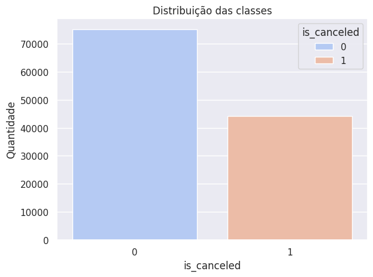

```python
print(balData)
churn_plot = sns.countplot(data=df, x='is_canceled', order=df.is_canceled.value_counts().index, hue= 'is_canceled', palette='coolwarm')

plt.title('Distribuição das classes')
plt.ylabel('Quantidade')

plt.tight_layout()
plt.show()
```

#### 3.1.3 Preditores Categóricos

Durante a análise exploratória, identificamos que o conjunto de dados contém variáveis **categóricas** que são aquelas que representam **categorias** seja elas nominais ou ordinais. Elas auxiliam para mapear o entender o evento que estamos analisando.

```python
x_categoricos =  df.select_dtypes(include=['object'])
x_categoricos['is_canceled'] = df['is_canceled']
x_categoricos.head()
```

|  | hotel | arrival_date_month | meal | country | market_segment | distribution_channel | reserved_room_type | assigned_room_type | deposit_type | customer_type | reservation_status | reservation_status_date | is_canceled |
| --- | --- | --- | --- | --- | --- | --- | --- | --- | --- | --- | --- | --- | --- |
| 0 | Resort Hotel | July | BB | PRT | Direct | Direct | C | C | No Deposit | Transient | Check-Out | 2015-07-01 | 0 |
| 1 | Resort Hotel | July | BB | PRT | Direct | Direct | C | C | No Deposit | Transient | Check-Out | 2015-07-01 | 0 |
| 2 | Resort Hotel | July | BB | GBR | Direct | Direct | A | C | No Deposit | Transient | Check-Out | 2015-07-02 | 0 |
| 3 | Resort Hotel | July | BB | GBR | Corporate | Corporate | A | A | No Deposit | Transient | Check-Out | 2015-07-02 | 0 |
| 4 | Resort Hotel | July | BB | GBR | Online TA | TA/TO | A | A | No Deposit | Transient | Check-Out | 2015-07-03 | 0 |

```python
x_categoricos.columns
```

```
Index(['hotel', 'arrival_date_month', 'meal', 'country', 'market_segment',
       'distribution_channel', 'reserved_room_type', 'assigned_room_type',
       'deposit_type', 'customer_type', 'reservation_status',
       'reservation_status_date', 'is_canceled'],
      dtype='object')
```

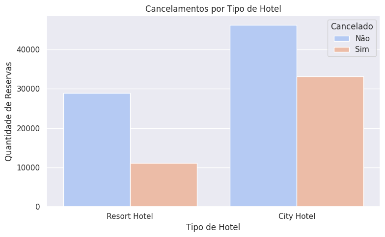

```python
plt.figure(figsize=(8,5))
sns.countplot(data=df, x='hotel', hue='is_canceled', palette= 'coolwarm')

plt.title("Cancelamentos por Tipo de Hotel")
plt.xlabel("Tipo de Hotel")
plt.ylabel("Quantidade de Reservas")
plt.legend(title="Cancelado", labels=["Não", "Sim"])

plt.tight_layout()
plt.show()
```

O número absoluto de cancelamentos no **City Hotel** é muito maior do que no **Resort Hotel**.

No **City Hotel**, a proporção entre reservas canceladas e concluídas está mais equilibrada, sugerindo que os hóspedes desse tipo de hotel têm maior propensão ao cancelamento.

O **Resort Hotel** apresenta uma proporção significativamente menor de cancelamentos em relação ao total de reservas. Isso pode indicar diferenças no perfil dos clientes ou no tipo de estadia esperada para cada hotel.

No **City Hotel**, por exemplo, podem ocorrer mais cancelamentos devido a mudanças em viagens a trabalho ou estadias curtas, enquanto no Resort Hotel, as reservas são mais planejadas e menos propensas a cancelamento.

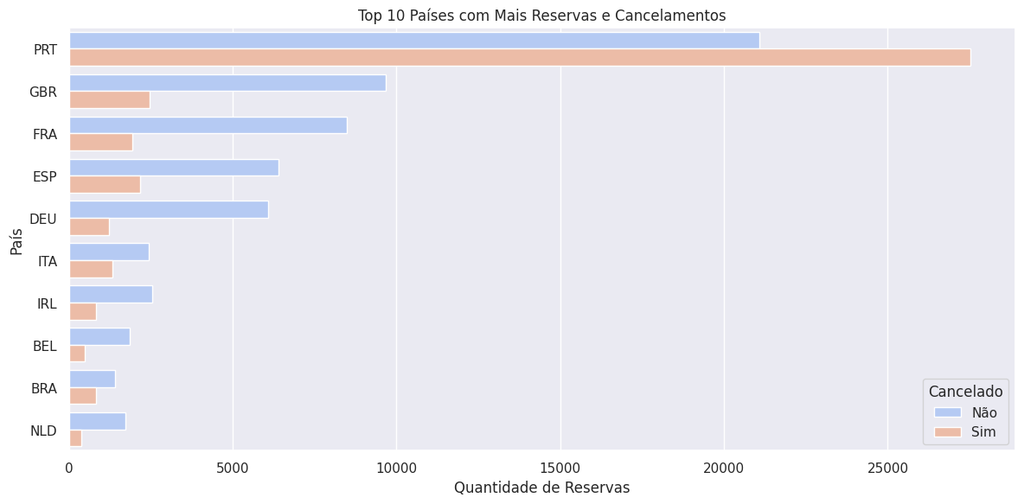

```python
top_countries = df['country'].value_counts().nlargest(10).index
df_country = df[df['country'].isin(top_countries)]

plt.figure(figsize=(12,6))
sns.countplot(data=df_country, y='country', hue='is_canceled', palette='coolwarm', order=top_countries)

plt.title("Top 10 Países com Mais Reservas e Cancelamentos")
plt.xlabel("Quantidade de Reservas")
plt.ylabel("País")
plt.legend(title="Cancelado", labels=["Não", "Sim"])

plt.tight_layout()
plt.show()
```

O maior volume de reservas vem de **Portugal**, e o número de cancelamentos também é expressivo, indicando que turistas portugueses fazem muitas reservas, mas também cancelam em uma proporção elevada. Reino Unido (GBR) e França (FRA) seguem em volume de reservas, ambos os países têm um número significativo de reservas, mas a taxa de cancelamento parece menor em comparação com Portugal.

Em países como Alemanha (DEU), Espanha (ESP) e Itália (ITA), a proporção de cancelamentos em relação ao total de reservas parece ser mais baixa. Brasil (BRA) aparece entre os 10 principais, não é tão alto quanto os países europeus, mas ainda assim figura entre os mais relevantes.

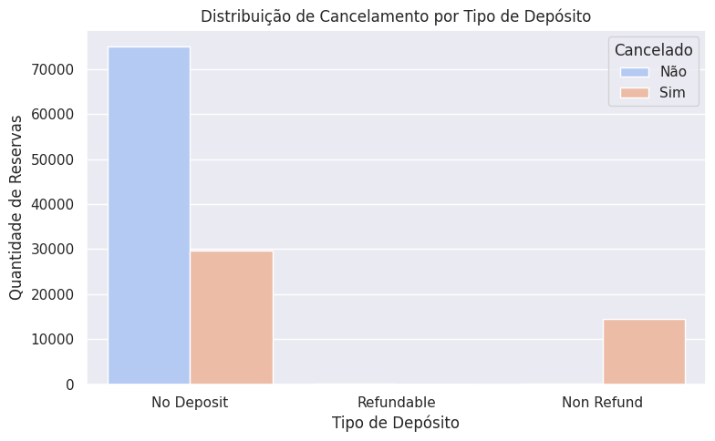

```python
plt.figure(figsize=(8,5))
sns.countplot(data=df, x='deposit_type', hue='is_canceled', palette='coolwarm')

plt.title("Distribuição de Cancelamento por Tipo de Depósito")
plt.xlabel("Tipo de Depósito")
plt.ylabel("Quantidade de Reservas")
plt.legend(title="Cancelado", labels=["Não", "Sim"])

plt.tight_layout()
plt.show()
```

[figure not shown]

```python
plt.figure(figsize=(12,6))
sns.histplot(data=df, x='arrival_date_month', hue='is_canceled', multiple='stack', palette='coolwarm', shrink=0.8)

plt.title("Reservas e Cancelamentos por Mês")
plt.xlabel("Mês de Chegada")
plt.ylabel("Quantidade de Reservas")
plt.xticks(rotation=45)
plt.legend(title="Cancelado", labels=["Não", "Sim"])

plt.tight_layout()
plt.show()
```

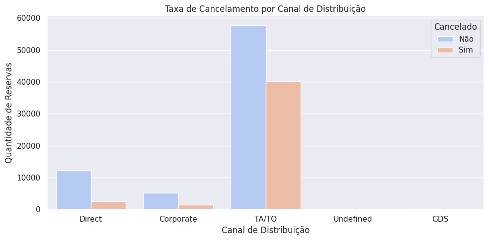

```python
plt.figure(figsize=(10,5))
sns.countplot(data=df, x='distribution_channel', hue='is_canceled', palette='coolwarm')

plt.title("Taxa de Cancelamento por Canal de Distribuição")
plt.xlabel("Canal de Distribuição")
plt.ylabel("Quantidade de Reservas")
plt.legend(title="Cancelado", labels=["Não", "Sim"])

plt.tight_layout()
plt.show()
```

O canal "TA/TO" (Agências de Viagem e Operadoras de Turismo) tem a maior quantidade de reservas e cancelamentos, esse canal representa a maioria das reservas, mas também exibe um alto volume de cancelamentos. Pode indicar que reservas feitas por agências e operadoras são mais suscetíveis a alterações, cancelamentos ou mudanças por parte dos clientes.

Reservas feitas diretamente ("Direct") possuem um volume considerável de reservas com menor taxa de cancelamento, o número de cancelamentos é relativamente baixo, sugerindo que clientes que fazem reservas diretamente no hotel tendem a ser mais comprometidos.

#### 3.1.4 Preditores Numéricos

As **variáveis numéricas** desempenham um papel crucial na construção de modelos preditivos, pois capturam informações quantitativas que podem influenciar diretamente a probabilidade de cancelamento.

```python
x_numericos = df.select_dtypes(include=['int64', 'float64'])
```

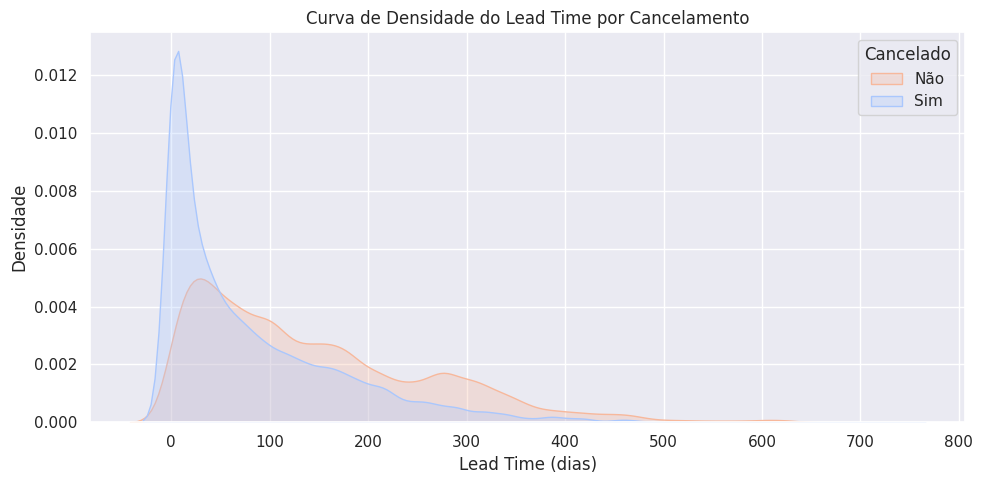

```python
plt.figure(figsize=(10, 5))
sns.kdeplot(data=df, x="lead_time", hue="is_canceled", common_norm=False, fill=True, alpha=0.3, palette='coolwarm')

plt.xlabel("Lead Time (dias)")
plt.ylabel("Densidade")
plt.title("Curva de Densidade do Lead Time por Cancelamento")
plt.legend(title="Cancelado", labels=["Não", "Sim"])

plt.tight_layout()
plt.show()
```

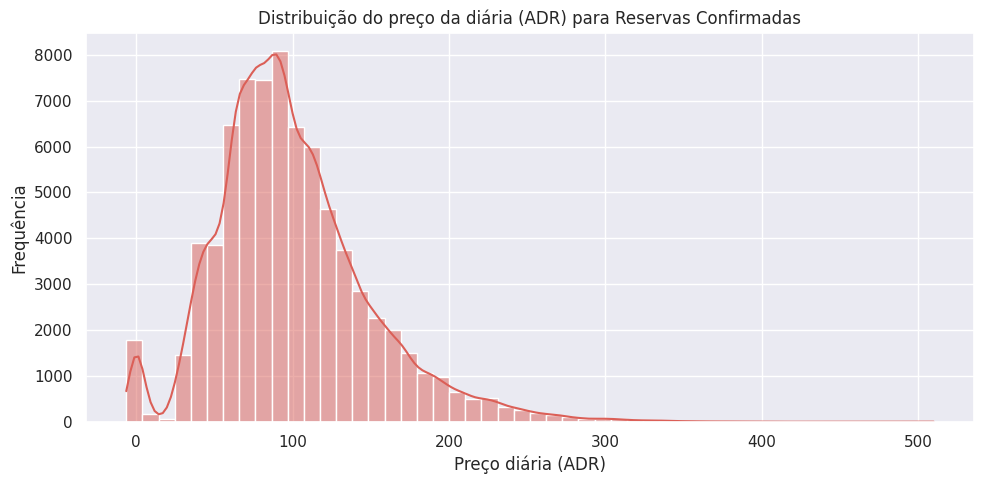

```python
plt.figure(figsize=(10, 5))
sns.histplot(df[df["is_canceled"] == 0]["adr"], bins=50, kde=True, palette='coolwarm')

plt.xlabel("Preço diária (ADR)")
plt.ylabel("Frequência")
plt.title("Distribuição do preço da diária (ADR) para Reservas Confirmadas")

plt.tight_layout()
plt.show()
```

O preço da diária segue uma distribuição assimétrica, onde a maioria das reservas confirmadas se concentra em valores intermediários. A maioria das diárias está concentrada entre 50 e 150 unidades monetárias, com um pico por volta de 100.

Existem algumas diárias acima de 200, mas com menor frequência. Isso sugere que preços muito altos são raros e representam hotéis premium ou pacotes especiais.

Há uma pequena concentração de reservas com valores muito baixos (~0 a 20). Isso pode indicar erros na base de dados, reservas promocionais ou registros que precisam ser melhor investigados.

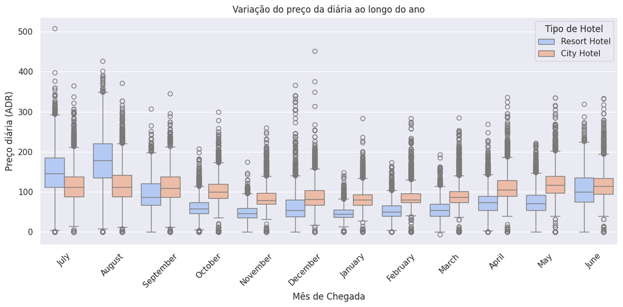

```python
plt.figure(figsize=(12, 6))
sns.boxplot(data=df[df["is_canceled"] == 0], x="arrival_date_month", y="adr", hue="hotel", palette='coolwarm')

plt.xlabel("Mês de Chegada")
plt.ylabel("Preço diária (ADR)")
plt.title("Variação do preço da diária ao longo do ano")
plt.legend(title="Tipo de Hotel")
plt.xticks(rotation=45)

plt.tight_layout()
plt.show()
```

1️⃣ Sazonalidade Clara: Os meses de junho, julho e agosto apresentam os maiores preços médios, indicando alta temporada. Já os meses de janeiro a março possuem preços mais baixos, sugerindo baixa demanda.

2️⃣ Diferença entre os Tipos de Hotéis: **City Hotel** possuem preços mais altos em geral, além de apresentar menor variação ao longo do ano.

3️⃣ Distribuição e Outliers: Há outliers frequentes, principalmente nos meses de alta temporada, indicando algumas diárias muito acima da média. A dispersão de preços é maior nos **Resort Hotels**, sugerindo uma gama de preços mais ampla, possivelmente devido a diferentes categorias de quartos e pacotes.

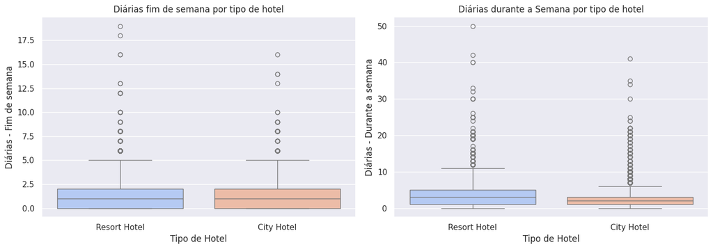

```python
fig, axes = plt.subplots(1, 2, figsize=(14, 5))

sns.boxplot(data=df, x="hotel", y="stays_in_weekend_nights", ax=axes[0], palette='coolwarm')
axes[0].set_title("Diárias fim de semana por tipo de hotel")
axes[0].set_xlabel("Tipo de Hotel")
axes[0].set_ylabel("Diárias - Fim de semana")

sns.boxplot(data=df, x="hotel", y="stays_in_week_nights", ax=axes[1], palette='coolwarm')
axes[1].set_title("Diárias durante a Semana por tipo de hotel")
axes[1].set_xlabel("Tipo de Hotel")
axes[1].set_ylabel("Diárias - Durante a semana")

plt.tight_layout()
plt.show()
```

O número de diárias durante a semana é maior do que nos fins de semana, indicando que muitas reservas são para estadias prolongadas. Isso sugere que os hóspedes, especialmente em hotéis Resort, ficam mais tempo durante a semana.

Ambos os tipos de hotéis apresentam um comportamento similar, a maioria das reservas tem poucas diárias (1 a 3 noites). No entanto, há outliers significativos em ambos os gráficos, mostrando que alguns hóspedes ficam por períodos muito longos, principalmente em Resort Hotels.

No gráfico de dias da semana, há mais valores extremos, com estadias chegando a 50 noites, o que pode indicar clientes corporativos ou contratos de longo prazo. No gráfico de fins de semana, os outliers são menos frequentes, e a maior parte das estadias fica em torno de 1 a 2 noites.

##### 3.1.4.1 Distribuição dos Dados – Assimetria (*Skewness*) e Curtose (*Kurtosis*)

Nesta etapa, será analisada a **distribuição dos dados** de cada variável, com foco em duas medidas estatísticas importantes: **assimetria** (*skewness*) e **curtose** (*kurtosis*).

- **Assimetria (*Skewness*)**: Indica o grau de **simetria** da distribuição dos dados em relação à média.
  - Uma distribuição **simétrica** tem skew próximo de **0**.
  - Assimetria **positiva** (skew > 0) indica concentração de valores à **esquerda**, com cauda alongada à **direita**.
  - Assimetria **negativa** (skew < 0) indica concentração à **direita**, com cauda alongada à **esquerda**.
- **Curtose (*Kurtosis*)**: Mede o grau de **achatamento** ou **picos** da distribuição em comparação com a distribuição normal.
  - Curtose **próxima de 0** indica uma distribuição semelhante à **normal**.
  - Curtose **positiva** indica uma distribuição com **picos acentuados** e caudas mais longas (**leptocúrtica**).
  - Curtose **negativa** indica uma distribuição mais **achatada** (**platicúrtica**).

Muitos algoritmos de **Machine Learning** pressupõem que as variáveis possuem uma **distribuição normal (gaussiana)**. Avaliar a **assimetria** e a **curtose** permite aplicar técnicas de **pré-processamento** adequadas (como transformação logarítmica, normalização ou padronização) para ajustar a distribuição dos dados. Esse ajuste pode melhorar significativamente a **performance** e a **acurácia** do modelo preditivo.

```python
x_numericos.skew()
```

```
is_canceled                        0.536678
lead_time                          1.346550
arrival_date_year                 -0.232583
arrival_date_week_number          -0.010014
arrival_date_day_of_month         -0.002000
stays_in_weekend_nights            1.380046
stays_in_week_nights               2.862249
adults                            18.317805
children                           4.112590
babies                            24.646545
is_repeated_guest                  5.326315
previous_cancellations            24.458049
previous_bookings_not_canceled    23.539800
booking_changes                    6.000270
agent                              1.089386
company                            0.601600
days_in_waiting_list              11.944353
adr                               10.530214
required_car_parking_spaces        4.163233
total_of_special_requests          1.349189
dtype: float64
```

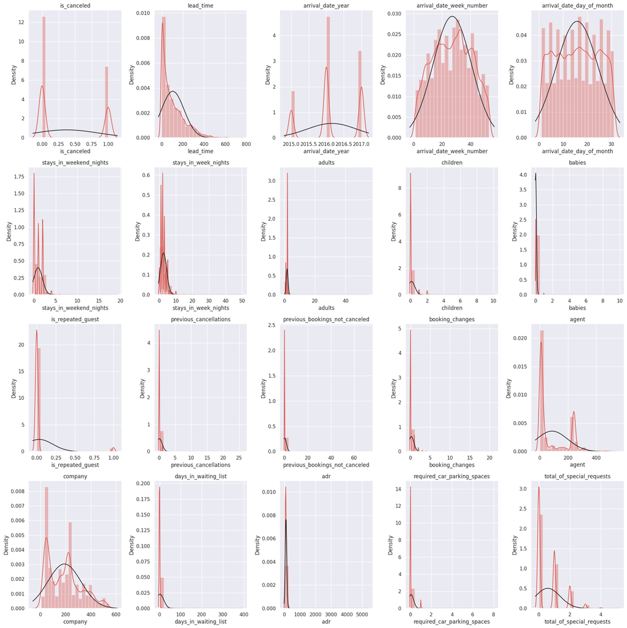

```python
fig, ((ax1, ax2, ax3, ax4, ax5),
      (ax6, ax7, ax8, ax9, ax10),
      (ax11, ax12, ax13, ax14, ax15),
      (ax16, ax17, ax18, ax19, ax20)) = plt.subplots(4, 5, figsize=(20, 20))

ax = [ax1, ax2, ax3, ax4, ax5, ax6, ax7, ax8, ax9, ax10, ax11, ax12, ax13, ax14, ax15, ax16, ax17, ax18, ax19, ax20]

for coluna in range(len(x_numericos.columns)):
    sns.distplot(x_numericos.iloc[:, coluna], bins=20, hist=True, ax=ax[coluna], fit=stats.norm)
    ax[coluna].set_title(x_numericos.columns[coluna])

plt.tight_layout()
plt.show()
```

Buscaremos agora compreender a força e direção de uma relação linear entre a variável independente e dependente.

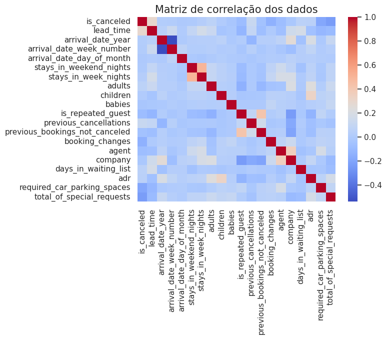

```python
sns.heatmap(x_numericos.corr(),annot = False, cmap="coolwarm")
plt.title("Matriz de correlação dos dados",fontsize= 15)
plt.show()
```

Distribuições Extremamente Assimétricas (Alta Skewness): `lead_time`: Enviesado à direita, com muitas reservas de curto prazo e algumas poucas de longuíssimo prazo. `adr`: Alto pico em valores baixos e uma longa cauda à direita, indicando a presença de preços de diária muito elevados. `previous_cancellations` e `previous_bookings_not_canceled`: Muitos valores próximos de zero e uma longa cauda, indicando que a maioria das reservas não teve cancelamentos prévios, mas algumas poucas tiveram um histórico extenso. `days_in_waiting_list`: A maioria das reservas não espera, mas algumas poucas esperam muito tempo.

Distribuições Moderadamente Assimétricas: `stays_in_weekend_nights` e `stays_in_week_nights`: Maior concentração de valores baixos, com poucas reservas de longuíssima duração. `total_of_special_requests`: A maioria das reservas faz poucos pedidos especiais, mas há alguns casos com muitos pedidos. `agent`: Alguns agentes dominam a distribuição das reservas, criando um viés.

##### 3.1.4.2 Identificação de *Outliers*

A análise de **outliers** é uma etapa essencial no processo de pré-processamento de dados, pois valores extremos podem distorcer estatísticas descritivas e impactar negativamente o desempenho dos modelos de **Machine Learning**.

Para identificar esses pontos fora do padrão, utilizaremos **boxplots**, que oferecem uma representação visual da **distribuição** de cada variável. A interpretação do boxplot inclui:

- A **linha central** da caixa representa a **mediana** (50º percentil).
- A borda inferior da caixa indica o **primeiro quartil (Q1 - 25%)**.
- A borda superior da caixa indica o **terceiro quartil (Q3 - 75%)**.
- As **extensões** se estendem até o menor e maior valor dentro de **1,5 vezes o intervalo interquartílico (IQR)**.
- **Pontos fora do boxplot** são considerados **outliers**.

Identificar outliers permite compreender melhor a **dispersão dos dados** e avaliar a necessidade de **tratamento adequado**, como remoção ou transformação desses valores. Essa análise contribui para melhorar a **qualidade dos dados** e aumentar a **robustez** do modelo preditivo.

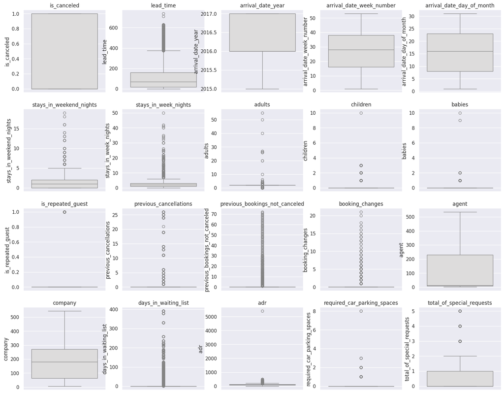

```python
# Configurando o tamanho da figura e o layout dos subplots
num_cols = 5  # Número de colunas de subplots
num_rows = len(x_numericos.columns) // num_cols + (len(x_numericos.columns) % num_cols > 0)
fig, axes = plt.subplots(num_rows, num_cols, figsize=(20, 4 * num_rows))

# Flatten the axes array for easy iteration
axes = axes.flatten()

# Loop para criar um boxplot para cada coluna numérica
for i, col in enumerate(x_numericos.columns):
    sns.boxplot(y=df[col], ax=axes[i], palette='coolwarm')
    axes[i].set_title(col)

# Remover subplots vazios
for j in range(i + 1, len(axes)):
    fig.delaxes(axes[j])
```

Considerando a definição clássica de outliers — valores que excedem 1,5 vezes o intervalo interquartílico (IQR) —, identificamos que algumas variáveis apresentam valores extremos. No entanto, antes de decidir por sua remoção ou transformação, é fundamental analisar o contexto dos dados para garantir que essas observações não representem simplesmente características naturais do fenômeno estudado.

Entre as variáveis com maior quantidade de outliers visíveis estão:

`lead_time`: Algumas reservas possuem um tempo de antecedência muito elevado (acima de 600 dias). Embora seja um valor extremo, ele pode ser legítimo em casos de reservas feitas com muita antecedência, especialmente para eventos ou períodos de alta demanda.

`adr` (Preço da Diária): Apresenta uma distribuição altamente assimétrica, com valores extremamente altos. Esses valores podem indicar suítes de luxo ou períodos de preços elevados, como feriados e alta temporada. Excluir esses dados poderia remover informações importantes sobre a precificação dinâmica dos hotéis.

`stays_in_weekend_nights` e `stays_in_week_nights`: Algumas reservas apresentam um número muito alto de noites, o que pode indicar hospedagens atípicas ou contratos de longa duração. Dependendo do objetivo do modelo, pode ser interessante categorizá-los em diferentes faixas de duração.

`previous_cancellations` e `previous_bookings_not_canceled`: Alguns hóspedes possuem um número elevado de reservas anteriores, o que pode representar clientes corporativos ou usuários com comportamento recorrente de reserva e cancelamento. Esses valores são relevantes e devem ser mantidos para análise de padrões de cancelamento.

`days_in_waiting_list`: A maioria das reservas não passa tempo na lista de espera, mas alguns registros apresentam valores altos. Esse dado pode ser importante para entender a demanda por determinados períodos.

Dado que os valores extremos observados não são necessariamente erros e refletem comportamentos reais do mercado hoteleiro, optamos por não remover diretamente esses dados.

Nesta fase de exploração dos dados vemos que:

1. Há dados faltantes.
2. Existe uma predominância nos dados de *feature* categórica, que enseja no uso de técnicas de *dummie's*.
3. Algumas features não tem poder preditivo.
4. Ficou claro que um dos pressupostos da classificação foi atendido parcealmente, há um leve desbalaceamento de classes das variável a ser predita, que iremos usar no modelo e ver o comportamento.
5. Poderíamos ter feito (a) correlações, (b) re-shape dos dados, (c) alterado variáveis categóricas para apenas binária... enfim, é muito vasto a fase de exploração. Para nosso propósito acredito já ser suficiente.

Iniciaremos a fase de preparar os dados para apresentá-los ao modelo preditivo.

## 4. Pré-Processamento dos Dados

### **Preparando os Dados para Machine Learning**

O **pré-processamento dos dados** é uma etapa fundamental no desenvolvimento de modelos de **Machine Learning**, pois muitos algoritmos exigem que os dados estejam em formatos específicos e adequadamente preparados para garantir um desempenho eficiente. Essa preparação inclui desde o **tratamento de dados ausentes**, **normalização** e **padronização** até a **codificação de variáveis categóricas** e **remoção de outliers**.

**Importância do Pré-Processamento:**

- **Melhora a performance** e a **eficiência** dos algoritmos.
- Garante que os dados estejam em um formato **compatível** com o modelo.
- **Reduz ruídos** e **viéses**, aumentando a **precisão** das previsões.

Explorar diferentes técnicas de preparação de dados e avaliar seu impacto no desempenho dos modelos faz parte do processo iterativo da **Ciência de Dados**. Essa experimentação é essencial para desenvolver soluções robustas e eficazes.

**Testar diferentes abordagens é uma das partes mais interessantes e criativas da Ciência de Dados!**

### 4.1 Transformação de Variáveis/Atributos

```python
df.head()
```

|  | hotel | is_canceled | lead_time | arrival_date_year | arrival_date_month | arrival_date_week_number | arrival_date_day_of_month | stays_in_weekend_nights | stays_in_week_nights | adults | ... | deposit_type | agent | company | days_in_waiting_list | customer_type | adr | required_car_parking_spaces | total_of_special_requests | reservation_status | reservation_status_date |
| --- | --- | --- | --- | --- | --- | --- | --- | --- | --- | --- | --- | --- | --- | --- | --- | --- | --- | --- | --- | --- | --- |
| 0 | Resort Hotel | 0 | 342 | 2015 | July | 27 | 1 | 0 | 0 | 2 | ... | No Deposit | NaN | NaN | 0 | Transient | 0.0 | 0 | 0 | Check-Out | 2015-07-01 |
| 1 | Resort Hotel | 0 | 737 | 2015 | July | 27 | 1 | 0 | 0 | 2 | ... | No Deposit | NaN | NaN | 0 | Transient | 0.0 | 0 | 0 | Check-Out | 2015-07-01 |
| 2 | Resort Hotel | 0 | 7 | 2015 | July | 27 | 1 | 0 | 1 | 1 | ... | No Deposit | NaN | NaN | 0 | Transient | 75.0 | 0 | 0 | Check-Out | 2015-07-02 |
| 3 | Resort Hotel | 0 | 13 | 2015 | July | 27 | 1 | 0 | 1 | 1 | ... | No Deposit | 304.0 | NaN | 0 | Transient | 75.0 | 0 | 0 | Check-Out | 2015-07-02 |
| 4 | Resort Hotel | 0 | 14 | 2015 | July | 27 | 1 | 0 | 2 | 2 | ... | No Deposit | 240.0 | NaN | 0 | Transient | 98.0 | 0 | 1 | Check-Out | 2015-07-03 |

5 rows × 32 columns

```python
df_proc = df.copy()
df_proc.head()
```

|  | hotel | is_canceled | lead_time | arrival_date_year | arrival_date_month | arrival_date_week_number | arrival_date_day_of_month | stays_in_weekend_nights | stays_in_week_nights | adults | ... | deposit_type | agent | company | days_in_waiting_list | customer_type | adr | required_car_parking_spaces | total_of_special_requests | reservation_status | reservation_status_date |
| --- | --- | --- | --- | --- | --- | --- | --- | --- | --- | --- | --- | --- | --- | --- | --- | --- | --- | --- | --- | --- | --- |
| 0 | Resort Hotel | 0 | 342 | 2015 | July | 27 | 1 | 0 | 0 | 2 | ... | No Deposit | NaN | NaN | 0 | Transient | 0.0 | 0 | 0 | Check-Out | 2015-07-01 |
| 1 | Resort Hotel | 0 | 737 | 2015 | July | 27 | 1 | 0 | 0 | 2 | ... | No Deposit | NaN | NaN | 0 | Transient | 0.0 | 0 | 0 | Check-Out | 2015-07-01 |
| 2 | Resort Hotel | 0 | 7 | 2015 | July | 27 | 1 | 0 | 1 | 1 | ... | No Deposit | NaN | NaN | 0 | Transient | 75.0 | 0 | 0 | Check-Out | 2015-07-02 |
| 3 | Resort Hotel | 0 | 13 | 2015 | July | 27 | 1 | 0 | 1 | 1 | ... | No Deposit | 304.0 | NaN | 0 | Transient | 75.0 | 0 | 0 | Check-Out | 2015-07-02 |
| 4 | Resort Hotel | 0 | 14 | 2015 | July | 27 | 1 | 0 | 2 | 2 | ... | No Deposit | 240.0 | NaN | 0 | Transient | 98.0 | 0 | 1 | Check-Out | 2015-07-03 |

5 rows × 32 columns

#### 4.1.1 Imputação de Valores Ausentes

A imputação de valores ausentes deve ser realizada com cuidado, considerando o tipo de variável (numérica ou categórica) e a distribuição dos dados. Abaixo estão dois métodos amplamente utilizados para **variáveis numéricas**:

**Imputação pela Mediana**  
A substituição de valores ausentes pela **mediana** é recomendada quando a variável possui **outliers**, pois a mediana é menos sensível a valores extremos do que a média.

**Implementação com `SimpleImputer`:**

```
from sklearn.impute import SimpleImputer
import numpy as np

# Criando o imputador com estratégia de mediana
imp_num = SimpleImputer(missing_values=np.nan, strategy='median', add_indicator=True)

# Aplicando a imputação nos dados
dados_imputados = imp_num.fit_transform(dados)
```

```python
pct_miss = 100*df.isnull().sum()/len(df)
pct_miss[(-pct_miss).argsort()]
```

```
company                           94.306893
agent                             13.686238
country                            0.408744
children                           0.003350
hotel                              0.000000
total_of_special_requests          0.000000
required_car_parking_spaces        0.000000
adr                                0.000000
customer_type                      0.000000
days_in_waiting_list               0.000000
deposit_type                       0.000000
booking_changes                    0.000000
assigned_room_type                 0.000000
reserved_room_type                 0.000000
previous_bookings_not_canceled     0.000000
previous_cancellations             0.000000
distribution_channel               0.000000
reservation_status                 0.000000
market_segment                     0.000000
meal                               0.000000
babies                             0.000000
adults                             0.000000
stays_in_week_nights               0.000000
stays_in_weekend_nights            0.000000
arrival_date_day_of_month          0.000000
arrival_date_week_number           0.000000
arrival_date_month                 0.000000
arrival_date_year                  0.000000
lead_time                          0.000000
is_canceled                        0.000000
is_repeated_guest                  0.000000
reservation_status_date            0.000000
dtype: float64
```

Iremos excluir as variaveis `company`e `agent` considerando (i) quantidade elevada de dados missing e a (ii) baixa capacidade de entregar relevancia o modelo, identificando no dicionário de dados perceberemos que são ID.

Definimos excluir as variáveis `country` e `reservation_status_date`, a primeira no processo de transformar a variável em numérica, devido a sua grande quantidade de registros categóricos únicos (177) poderia aumentar a dimensionalidade dos dados, já a segunda assuminos *a priore* que não possui valor preditivo. (PS(i). essas 2 variáveis so chegamos a essa conclusão quando estávamos desenvolvendo o passo 4.1.2)

Exluiremos também a variável `reservation_status` pois o modelo pode haver um "vazamento de informção" e o modelo não conseguirá generalizar pois essa feature, ao que parece, ocorre posterior a variável target. (PS(ii). treinamos o modelo com essa variavel e teve um overfitting)

Já para `children` vamos excluir os registros dado a quantidade de obsrvações geral que temos,

```python
print(f'dados antes do tratamento de missing values: {df_proc.shape}')
```

```
dados antes do tratamento de missing values: (119390, 32)
```

```python
df_proc= df_proc.drop(columns=['company', 'agent', 'country', 'reservation_status_date', 'reservation_status'])
print(f'dados após o primeiro tratamento de missing values: {df_proc.shape}')
```

```
dados após o primeiro tratamento de missing values: (119390, 27)
```

```python
df_proc= df_proc.dropna(subset=['children'])
print(f'dados após o segundo tratamento de missing values: {df_proc.shape}')
```

```
dados após o segundo tratamento de missing values: (119386, 27)
```

#### 4.1.2 Codificação de Variáveis Categóricas (*Dummies*)

Para que os algoritmos de Machine Learning possam processar corretamente os dados, todas as variáveis precisam estar em formato numérico. Como muitas variáveis categóricas contêm informações importantes para o modelo, é necessário convertê-las para valores numéricos sem perder informação semântica. Esse processo é conhecido como codificação de variáveis categóricas.

A técnica de codificação utilizada depende do tipo de variável categórica:

Codificação de Variáveis **Binárias**:

Quando a variável possui apenas duas categorias distintas (ex.: Gender com valores Masculino e Feminino), a abordagem mais eficiente é a codificação ordinal.

✅ Método Utilizado: LabelEncoder

Atribui um valor numérico sequencial para representar cada categoria. Exemplo: Masculino → 0 Feminino → 1 Essa abordagem é simples e evita a criação de colunas adicionais, tornando o modelo mais eficiente.

Codificação de Variáveis **Multiclasse**:

Quando a variável contém mais de duas categorias distintas (ex.: Market_Segment, Deposit_Type, Meal), o método mais adequado é a codificação One-Hot Encoding.

✅ Método Utilizado: pd.get_dummies()

Cria colunas binárias para cada categoria, onde cada coluna indica a presença (1) ou ausência (0) daquela categoria na amostra.

Atenção à Dimensionalidade dos Dados!

Criar muitas colunas adicionais pode aumentar significativamente a dimensionalidade do dataset, tornando o modelo mais complexo e podendo levar a overfitting. Para evitar redundância, recomenda-se excluir uma das colunas geradas (evitar *dummy variable trap* - efeito da multicolinearidade).

```python
df_proc[df_proc.select_dtypes(include=['object']).columns].nunique().sort_values(ascending=True)
```

```
hotel                    2
deposit_type             3
customer_type            4
meal                     5
distribution_channel     5
market_segment           7
reserved_room_type      10
arrival_date_month      12
assigned_room_type      12
dtype: int64
```

```python
df_proc.select_dtypes(include=['object']).columns
```

```
Index(['hotel', 'arrival_date_month', 'meal', 'market_segment',
       'distribution_channel', 'reserved_room_type', 'assigned_room_type',
       'deposit_type', 'customer_type'],
      dtype='object')
```

**Binárias**

```python
label_encoder = LabelEncoder()
```

```python
df_proc['hotel'] = label_encoder.fit_transform(df_proc['hotel'])
print(df_proc['hotel'].head())
```

```
0    1
1    1
2    1
3    1
4    1
Name: hotel, dtype: int64
```

```python
print(f'dataset antes do tratamento de variáveis categóricas: {df_proc.shape}')
```

```
dataset antes do tratamento de variáveis categóricas: (119386, 27)
```

**Multiclasse**

```python
colunas_dummies = ['arrival_date_month', 'meal', 'market_segment', 'distribution_channel', 'reserved_room_type',\
                    'assigned_room_type', 'deposit_type', 'customer_type']
```

```python
df_proc.head()
```

|  | hotel | is_canceled | lead_time | arrival_date_year | arrival_date_month | arrival_date_week_number | arrival_date_day_of_month | stays_in_weekend_nights | stays_in_week_nights | adults | ... | previous_bookings_not_canceled | reserved_room_type | assigned_room_type | booking_changes | deposit_type | days_in_waiting_list | customer_type | adr | required_car_parking_spaces | total_of_special_requests |
| --- | --- | --- | --- | --- | --- | --- | --- | --- | --- | --- | --- | --- | --- | --- | --- | --- | --- | --- | --- | --- | --- |
| 0 | 1 | 0 | 342 | 2015 | July | 27 | 1 | 0 | 0 | 2 | ... | 0 | C | C | 3 | No Deposit | 0 | Transient | 0.0 | 0 | 0 |
| 1 | 1 | 0 | 737 | 2015 | July | 27 | 1 | 0 | 0 | 2 | ... | 0 | C | C | 4 | No Deposit | 0 | Transient | 0.0 | 0 | 0 |
| 2 | 1 | 0 | 7 | 2015 | July | 27 | 1 | 0 | 1 | 1 | ... | 0 | A | C | 0 | No Deposit | 0 | Transient | 75.0 | 0 | 0 |
| 3 | 1 | 0 | 13 | 2015 | July | 27 | 1 | 0 | 1 | 1 | ... | 0 | A | A | 0 | No Deposit | 0 | Transient | 75.0 | 0 | 0 |
| 4 | 1 | 0 | 14 | 2015 | July | 27 | 1 | 0 | 2 | 2 | ... | 0 | A | A | 0 | No Deposit | 0 | Transient | 98.0 | 0 | 1 |

5 rows × 27 columns

`drop_first=True`: Este parâmetro indica que a primeira categoria de cada coluna categórica deve ser removida. Isso é feito para evitar a multicolinearidade em modelos de regressão. Quando você tem n categorias, você só precisa de n-1 variáveis dummy para representá-las, pois a última categoria pode ser inferida a partir das outras.

```python
df_proc = pd.get_dummies(df_proc, columns=colunas_dummies, dtype=int, drop_first=True)
print(f'dataset após o tratamento de variáveis categóricas: {df_proc.shape}')
```

```
dataset após o tratamento de variáveis categóricas: (119386, 69)
```

```python
df_proc.head()
```

|  | hotel | is_canceled | lead_time | arrival_date_year | arrival_date_week_number | arrival_date_day_of_month | stays_in_weekend_nights | stays_in_week_nights | adults | children | ... | assigned_room_type_H | assigned_room_type_I | assigned_room_type_K | assigned_room_type_L | assigned_room_type_P | deposit_type_Non Refund | deposit_type_Refundable | customer_type_Group | customer_type_Transient | customer_type_Transient-Party |
| --- | --- | --- | --- | --- | --- | --- | --- | --- | --- | --- | --- | --- | --- | --- | --- | --- | --- | --- | --- | --- | --- |
| 0 | 1 | 0 | 342 | 2015 | 27 | 1 | 0 | 0 | 2 | 0.0 | ... | 0 | 0 | 0 | 0 | 0 | 0 | 0 | 0 | 1 | 0 |
| 1 | 1 | 0 | 737 | 2015 | 27 | 1 | 0 | 0 | 2 | 0.0 | ... | 0 | 0 | 0 | 0 | 0 | 0 | 0 | 0 | 1 | 0 |
| 2 | 1 | 0 | 7 | 2015 | 27 | 1 | 0 | 1 | 1 | 0.0 | ... | 0 | 0 | 0 | 0 | 0 | 0 | 0 | 0 | 1 | 0 |
| 3 | 1 | 0 | 13 | 2015 | 27 | 1 | 0 | 1 | 1 | 0.0 | ... | 0 | 0 | 0 | 0 | 0 | 0 | 0 | 0 | 1 | 0 |
| 4 | 1 | 0 | 14 | 2015 | 27 | 1 | 0 | 2 | 2 | 0.0 | ... | 0 | 0 | 0 | 0 | 0 | 0 | 0 | 0 | 1 | 0 |

5 rows × 69 columns

```python
df_proc.info()
```

```
<class 'pandas.core.frame.DataFrame'>
Index: 119386 entries, 0 to 119389
Data columns (total 69 columns):
 #   Column                          Non-Null Count   Dtype
---  ------                          --------------   -----
 0   hotel                           119386 non-null  int64
 1   is_canceled                     119386 non-null  int64
 2   lead_time                       119386 non-null  int64
 3   arrival_date_year               119386 non-null  int64
 4   arrival_date_week_number        119386 non-null  int64
 5   arrival_date_day_of_month       119386 non-null  int64
 6   stays_in_weekend_nights         119386 non-null  int64
 7   stays_in_week_nights            119386 non-null  int64
 8   adults                          119386 non-null  int64
 9   children                        119386 non-null  float64
```

[output cut: 61 more lines]

```python
df_proc.corr()
```

|  | hotel | is_canceled | lead_time | arrival_date_year | arrival_date_week_number | arrival_date_day_of_month | stays_in_weekend_nights | stays_in_week_nights | adults | children | ... | assigned_room_type_H | assigned_room_type_I | assigned_room_type_K | assigned_room_type_L | assigned_room_type_P | deposit_type_Non Refund | deposit_type_Refundable | customer_type_Group | customer_type_Transient | customer_type_Transient-Party |
| --- | --- | --- | --- | --- | --- | --- | --- | --- | --- | --- | --- | --- | --- | --- | --- | --- | --- | --- | --- | --- | --- |
| hotel | 1.000000 | -0.136505 | -0.075405 | -0.035308 | -0.001261 | 0.001836 | 0.186595 | 0.234022 | 0.013199 | 0.044205 | ... | 0.108997 | 0.077712 | -0.034394 | 0.004073 | -0.003586 | -0.172014 | 0.042234 | 0.023120 | 0.005713 | -0.027768 |
| is_canceled | -0.136505 | 1.000000 | 0.293177 | 0.016732 | 0.008132 | -0.006084 | -0.001783 | 0.024771 | 0.059990 | 0.005048 | ... | -0.002866 | -0.040783 | -0.032811 | 0.003773 | 0.013072 | 0.481488 | -0.011310 | -0.038696 | 0.133170 | -0.124231 |
| lead_time | -0.075405 | 0.293177 | 1.000000 | 0.040093 | 0.126885 | 0.002234 | 0.085667 | 0.165799 | 0.119544 | -0.037622 | ... | -0.021101 | -0.019328 | -0.027952 | -0.002817 | -0.009759 | 0.380174 | 0.016586 | -0.031927 | -0.174026 | 0.159622 |
| arrival_date_year | -0.035308 | 0.016732 | 0.040093 | 1.000000 | -0.540566 | -0.000279 | 0.021489 | 0.030878 | 0.029674 | 0.054624 | ... | 0.001462 | 0.000249 | 0.008904 | -0.004732 | 0.004867 | -0.065987 | -0.000762 | -0.010987 | 0.227880 | -0.163499 |
| arrival_date_week_number | -0.001261 | 0.008132 | 0.126885 | -0.540566 | 1.000000 | 0.066824 | 0.018209 | 0.015559 | 0.025901 | 0.005518 | ... | 0.008424 | -0.004897 | 0.003531 | 0.000390 | 0.003133 | 0.007777 | -0.016887 | 0.011619 | -0.079526 | 0.042191 |
| ... | ... | ... | ... | ... | ... | ... | ... | ... | ... | ... | ... | ... | ... | ... | ... | ... | ... | ... | ... | ... | ... |
| deposit_type_Non Refund | -0.172014 | 0.481488 | 0.380174 | -0.065987 | 0.007777 | -0.008629 | -0.114279 | -0.080002 | -0.028972 | -0.096671 | ... | -0.028234 | -0.020139 | -0.018057 | -0.001080 | -0.003741 | 1.000000 | -0.013752 | -0.026000 | 0.115851 | -0.121434 |
| deposit_type_Refundable | 0.042234 | -0.011310 | 0.016586 | -0.000762 | -0.016887 | 0.032149 | 0.001761 | 0.006791 | 0.003247 | -0.006754 | ... | -0.002855 | -0.002036 | -0.001784 | -0.000107 | -0.000370 | -0.013752 | 1.000000 | 0.023679 | -0.053433 | 0.054660 |
| customer_type_Group | 0.023120 | -0.038696 | -0.031927 | -0.010987 | 0.011619 | -0.001551 | -0.007163 | -0.016182 | 0.058978 | -0.006650 | ... | -0.003829 | 0.007120 | 0.004131 | -0.000202 | 0.011349 | -0.026000 | 0.023679 | 1.000000 | -0.120903 | -0.035975 |
| customer_type_Transient | 0.005713 | 0.133170 | -0.174026 | 0.227880 | -0.079526 | -0.000670 | 0.019475 | 0.007292 | 0.091051 | 0.096135 | ... | 0.031823 | -0.007902 | 0.003840 | 0.001668 | 0.003848 | 0.115851 | -0.053433 | -0.120903 | 1.000000 | -0.895584 |
| customer_type_Transient-Party | -0.027768 | -0.124231 | 0.159622 | -0.163499 | 0.042191 | 0.006339 | -0.064914 | -0.064277 | -0.115814 | -0.092846 | ... | -0.027174 | 0.006950 | -0.002428 | -0.001494 | -0.005176 | -0.121434 | 0.054660 | -0.035975 | -0.895584 | 1.000000 |

69 rows × 69 columns

```python
pd.set_option('display.max_rows', None)
df_proc.corr().iloc[1]
```

```
hotel                            -0.136505
is_canceled                       1.000000
lead_time                         0.293177
arrival_date_year                 0.016732
arrival_date_week_number          0.008132
arrival_date_day_of_month        -0.006084
stays_in_weekend_nights          -0.001783
stays_in_week_nights              0.024771
adults                            0.059990
children                          0.005048
babies                           -0.032488
is_repeated_guest                -0.084788
previous_cancellations            0.110140
previous_bookings_not_canceled   -0.057355
booking_changes                  -0.144371
days_in_waiting_list              0.054193
adr                               0.047622
required_car_parking_spaces      -0.195492
total_of_special_requests        -0.234706
arrival_date_month_August         0.005223
arrival_date_month_December      -0.010513
arrival_date_month_February      -0.020201
arrival_date_month_January       -0.031064
arrival_date_month_July           0.002953
arrival_date_month_June           0.029054
arrival_date_month_March         -0.030254
arrival_date_month_May            0.018004
arrival_date_month_November      -0.029534
arrival_date_month_October        0.006697
arrival_date_month_September      0.013707
meal_FB                           0.038832
meal_HB                          -0.019829
meal_SC                           0.001296
meal_Undefined                   -0.025893
market_segment_Complementary     -0.039304
market_segment_Corporate         -0.081660
market_segment_Direct            -0.154420
market_segment_Groups             0.221886
market_segment_Offline TA/TO     -0.028451
market_segment_Online TA         -0.006269
```

[output cut: 15 more lines]

```
assigned_room_type_D             -0.128017
assigned_room_type_E             -0.064784
assigned_room_type_F             -0.045971
assigned_room_type_G             -0.019858
assigned_room_type_H             -0.002866
assigned_room_type_I             -0.040783
assigned_room_type_K             -0.032811
assigned_room_type_L              0.003773
assigned_room_type_P              0.013072
deposit_type_Non Refund           0.481488
deposit_type_Refundable          -0.011310
customer_type_Group              -0.038696
customer_type_Transient           0.133170
customer_type_Transient-Party    -0.124231
Name: is_canceled, dtype: float64
```

```python
pd.reset_option('display.max_rows')
```

Após a transformação das variáveis categóricas em numéricas por meio da técnica de dummies, analisamos a correlação entre essas variáveis e a variável alvo. Esse processo nos permitiu identificar quais atributos possuem maior potencial preditivo e quais apresentam uma relação fraca com o cancelamento das reservas.

Com base nos resultados, optamos por remover as variáveis cuja correlação foi insignificante, simplificando o modelo e reduzindo a complexidade sem perda substancial de informação. No entanto, é fundamental destacar que qualquer manipulação nos dados impacta diretamente o desempenho do modelo, podendo resultar tanto em melhorias quanto em perdas significativas de desempenho.

Por razões **didáticas**, seguiremos essa abordagem de exclusão, mas reforçamos que, em um processo mais refinado de *feature engineering*, seria recomendável explorar novas combinações de variáveis. Um exemplo seria a fusão das variáveis `children`, `babies` e `adults` em uma única variável `familia`, que poderia capturar melhor o comportamento dos hóspedes em relação ao cancelamento. Essa etapa de criação de novas features pode revelar relações ocultas e aprimorar a capacidade preditiva do modelo.

```python
df_proc.columns
```

```
Index(['hotel', 'is_canceled', 'lead_time', 'arrival_date_year',
       'arrival_date_week_number', 'arrival_date_day_of_month',
       'stays_in_weekend_nights', 'stays_in_week_nights', 'adults', 'children',
       'babies', 'is_repeated_guest', 'previous_cancellations',
       'previous_bookings_not_canceled', 'booking_changes',
       'days_in_waiting_list', 'adr', 'required_car_parking_spaces',
       'total_of_special_requests', 'arrival_date_month_August',
       'arrival_date_month_December', 'arrival_date_month_February',
       'arrival_date_month_January', 'arrival_date_month_July',
       'arrival_date_month_June', 'arrival_date_month_March',
       'arrival_date_month_May', 'arrival_date_month_November',
       'arrival_date_month_October', 'arrival_date_month_September', 'meal_FB',
       'meal_HB', 'meal_SC', 'meal_Undefined', 'market_segment_Complementary',
       'market_segment_Corporate', 'market_segment_Direct',
       'market_segment_Groups', 'market_segment_Offline TA/TO',
       'market_segment_Online TA', 'distribution_channel_Direct',
       'distribution_channel_GDS', 'distribution_channel_TA/TO',
       'distribution_channel_Undefined', 'reserved_room_type_B',
       'reserved_room_type_C', 'reserved_room_type_D', 'reserved_room_type_E',
       'reserved_room_type_F', 'reserved_room_type_G', 'reserved_room_type_H',
       'reserved_room_type_L', 'reserved_room_type_P', 'assigned_room_type_B',
       'assigned_room_type_C', 'assigned_room_type_D', 'assigned_room_type_E',
       'assigned_room_type_F', 'assigned_room_type_G', 'assigned_room_type_H',
       'assigned_room_type_I', 'assigned_room_type_K', 'assigned_room_type_L',
       'assigned_room_type_P', 'deposit_type_Non Refund',
       'deposit_type_Refundable', 'customer_type_Group',
       'customer_type_Transient', 'customer_type_Transient-Party'],
      dtype='object')
```

```python
df_proc= df_proc.drop(columns=[ 'arrival_date_month_August', 'arrival_date_month_December', 'arrival_date_month_February',\
                                'arrival_date_month_January', 'arrival_date_month_July', 'arrival_date_month_June', 'arrival_date_month_March',\
                                'arrival_date_month_May', 'arrival_date_month_November', 'arrival_date_month_October', 'arrival_date_month_September',\
                                'arrival_date_week_number', 'arrival_date_day_of_month', 'adults', 'children', 'babies', 'stays_in_weekend_nights', 'stays_in_week_nights'])
```

```python
print(f'dataset após o processamento: {df_proc.shape}')
```

```
dataset após o processamento: (119386, 51)
```

### 4.2 Split dados

Para avaliar o desempenho do modelo, é fundamental dividir os dados em conjuntos de treino e teste. Duas abordagens amplamente utilizadas são:

- (i) o método estático, implementado pela função train_test_split da biblioteca sklearn.model_selection, que separa os dados em uma única iteração; e
- (ii) a validação cruzada (Cross-validation), que realiza divisões aleatórias e avalia o modelo em diferentes subconjuntos para maior robustez.

Optamos pelo método estático, mantendo o *default* de 75% dos dados para treino e 25% para teste, garantindo simplicidade e uma divisão consistente para o desenvolvimento inicial do modelo.

#### 4.2.1 Estático

```python
df_proc.head()
```

|  | hotel | is_canceled | lead_time | arrival_date_year | is_repeated_guest | previous_cancellations | previous_bookings_not_canceled | booking_changes | days_in_waiting_list | adr | ... | assigned_room_type_H | assigned_room_type_I | assigned_room_type_K | assigned_room_type_L | assigned_room_type_P | deposit_type_Non Refund | deposit_type_Refundable | customer_type_Group | customer_type_Transient | customer_type_Transient-Party |
| --- | --- | --- | --- | --- | --- | --- | --- | --- | --- | --- | --- | --- | --- | --- | --- | --- | --- | --- | --- | --- | --- |
| 0 | 1 | 0 | 342 | 2015 | 0 | 0 | 0 | 3 | 0 | 0.0 | ... | 0 | 0 | 0 | 0 | 0 | 0 | 0 | 0 | 1 | 0 |
| 1 | 1 | 0 | 737 | 2015 | 0 | 0 | 0 | 4 | 0 | 0.0 | ... | 0 | 0 | 0 | 0 | 0 | 0 | 0 | 0 | 1 | 0 |
| 2 | 1 | 0 | 7 | 2015 | 0 | 0 | 0 | 0 | 0 | 75.0 | ... | 0 | 0 | 0 | 0 | 0 | 0 | 0 | 0 | 1 | 0 |
| 3 | 1 | 0 | 13 | 2015 | 0 | 0 | 0 | 0 | 0 | 75.0 | ... | 0 | 0 | 0 | 0 | 0 | 0 | 0 | 0 | 1 | 0 |
| 4 | 1 | 0 | 14 | 2015 | 0 | 0 | 0 | 0 | 0 | 98.0 | ... | 0 | 0 | 0 | 0 | 0 | 0 | 0 | 0 | 1 | 0 |

5 rows × 51 columns

```python
X = df_proc.drop(columns= ['is_canceled'], axis= 1)
y = df_proc.is_canceled
```

O parâmetro **`stratify=True`** assegura que a divisão dos dados em **conjuntos de treino e teste** mantenha a **proporção original das classes** da variável alvo, evitando desequilíbrios entre as categorias.

Já o parâmetro **`shuffle=True`** tem a função de **embaralhar aleatoriamente** os dados antes da divisão, garantindo que a separação entre treino e teste ocorra de forma **aleatória**, reduzindo o risco de viés nos conjuntos.

```python
X_treino, X_teste, y_treino, y_teste = train_test_split(X, y, stratify=y, shuffle=True)
```

```python
print('tamanho total dos dados são {}, para treino temos {} e teste são {}'.format(df_proc.shape[0], len(X_treino), len(X_teste)))
```

```
tamanho total dos dados são 119386, para treino temos 89539 e teste são 29847
```

### 4.3 Feature Engineer - II

#### 4.3.1.Balanceamento de classes

São técnicas para manter um "certo balancemanto" entre as classes, pois se temos classe majoritária o modelo de *ML*, possivelmente aprenderá mais sobre ela, logo temos um problema -> **modelo sem generalização**, devemos evitar!!.

Podemos utilizar:

- **Oversampling (Superamostragem)**: Aumentar a quantidade de registros da classe minoritária por meio da duplicação de dados ou geração de novas amostras sintéticas, como a técnica **SMOTE** (*Synthetic Minority Over-sampling Technique*).
- **Undersampling (Subamostragem)**: Reduzir a quantidade de registros da classe majoritária, eliminando amostras redundantes para equilibrar a proporção entre as classes.

**ATENÇÃO 1**: o ideal é sempre aplicar as técnicas depois de realizar o split dos dados (treino e teste). Se aplicar o balancemento antes, o padrão usado para aplicar o oversampling/undersampling será o mesmo nos dados de treino e de teste, com isso a avaliação do modelo fica comprometida.

**ATENÇÃO 2**: você ao tomar decisão de balancear os dados, diretamente está alterando seu conjunto de dados. Ou seja, saiba **o que** está fazendo e **para que** está fazendo!!!!

Conforme já dito anteriormente(*item [3.1.2.2]*), neste estudo a variável `is_canceled` apresenta um leve desbalanceamento, mas não em um nível que exija, de imediato, a aplicação de técnicas de balanceamento. Iremos treinar o modelo, assumindo esse leve desbalanceamento, muito embora seja realizado uma segunda versão buscando balancear as classes.

= output: dados pré-processados e splitados para iniciar a construção do modelo de ML

### **4.4 Avaliação de Multicolinearidade**

A **multicolinearidade** ocorre quando variáveis independentes estão altamente correlacionadas, o que pode distorcer os **coeficientes** do modelo, dificultar a **interpretação** e reduzir a **precisão preditiva**.

Para detectar esse problema, utiliza-se o **Fator de Inflação da Variância (VIF)**, que indica o quanto a variância de um coeficiente é ampliada pela correlação entre variáveis.

**Interpretação do VIF:**

- **VIF ≈ 1:** Baixa correlação (**sem multicolinearidade**).
- **VIF > 10:** Indica **multicolinearidade severa**.

**Tratamento da Multicolinearidade:**

- **Ajustar ou remover** variáveis com **VIF elevado** para melhorar a **robustez** e a **interpretabilidade** do modelo.
- Quando a remoção não for viável, aplicar **técnicas de regularização** como:
  - **Ridge Regression (L2):** Penaliza coeficientes grandes, suavizando o impacto de variáveis correlacionadas.
  - **Lasso Regression (L1):** Realiza **seleção de variáveis** ao reduzir coeficientes menos relevantes a zero.

Essas técnicas ajudam a mitigar a multicolinearidade sem a necessidade de excluir variáveis importantes.

X_treino, X_teste, y_treino, y_teste

```python
vif_data = pd.DataFrame()
vif_data['Feature'] = X_treino.columns
vif_data['VIF'] = [variance_inflation_factor(X_treino.values, i) for i in range(X_treino.shape[1])]

print("Valores de VIF para cada variável:")
print(vif_data)
```

[output not shown]

[output cut: 35 more lines]

Pelas features que ficaram com valores acima de 10, sugere-no usar no precesso de regressão logística algurma técnica de regularização.

## 5. Seleção de Algoritmos

### 5.1 Algoritmos de Classificação

A escolha do algoritmo de **classificação** mais adequado não é previsível, pois diferentes modelos podem apresentar desempenhos distintos dependendo das características dos dados. Por esse motivo, é essencial **ajustar** (*fit*) e **avaliar** diversos algoritmos de classificação no conjunto de dados. O objetivo é identificar o modelo que oferece o melhor **desempenho preditivo** e **generalização**.

```python
# Instanciar o modelo
ridge_model = LogisticRegression(penalty='l2', solver='lbfgs', max_iter=1000, random_state=42)

# Treinar o modelo
ridge_model.fit(X_treino, y_treino)
```

```
LogisticRegression(max_iter=1000, random_state=42)
```

```python
# Avaliar coeficientes após regularização
coef_df = pd.DataFrame({'Feature': X_treino.columns, 'Coefficient': ridge_model.coef_[0]})
print(coef_df.sort_values(by='Coefficient', ascending=False))
```

```
                           Feature  Coefficient
45         deposit_type_Non Refund     5.936046
4           previous_cancellations     3.406655
27            reserved_room_type_D     0.856323
20        market_segment_Online TA     0.765776
48         customer_type_Transient     0.532560
28            reserved_room_type_E     0.508711
11                         meal_FB     0.308719
26            reserved_room_type_C     0.245691
25            reserved_room_type_B     0.236302
0                            hotel     0.215996
23      distribution_channel_TA/TO     0.176384
13                         meal_SC     0.095766
15    market_segment_Complementary     0.069976
30            reserved_room_type_G     0.066661
```

[output cut: 36 more lines]

Os coeficientes apresentados representam o impacto de cada variável preditora na probabilidade de um cliente cancelar sua reserva em um hotel. Um coeficiente positivo indica que o aumento da variável preditora aumenta a probabilidade de cancelamento, enquanto um coeficiente negativo indica o oposto. A magnitude do coeficiente reflete a força da influência.

**Variáveis com Maior Impacto**:

`deposit_type_Non Refund`(5.936046): Este é o fator mais preditivo para cancelamentos. Depósitos não reembolsáveis estão fortemente associados a uma maior probabilidade de cancelamento, provavelmente porque os clientes que fazem esse tipo de depósito podem ter menos incentivo para manter a reserva se seus planos mudarem.

`previous_cancellations` (3.406655): Histórico de cancelamentos anteriores é um forte indicador de que um cliente poderá cancelar novamente.

`required_car_parking_spaces` (-3.714556): Este é o fator com maior impacto negativo. Clientes que precisam de vaga de estacionamento têm uma probabilidade significativamente menor de cancelar, sugerindo que a necessidade de estacionamento pode indicar uma viagem mais planejada e, portanto, menos propensa a ser cancelada.

**Variáveis com Impacto Moderado**:

`market_segment_Online TA` (0.765776): Reservas feitas através de agências de viagens online (OTAs) estão associadas a uma maior probabilidade de cancelamento, possivelmente devido à maior flexibilidade e concorrência de preços online.

`customer_type_Transient` (0.532560): Clientes que se hospedam no hotel sem fazer parte de um grupo ou evento têm maior probabilidade de cancelar.

`assigned_room_type_D` (-1.078639): Aparentemente, clientes que reservam quartos do tipo "D" têm uma chance menor de cancelar.

**Variáveis com Menor Impacto**: `meal_FB` (0.308719), `reserved_room_type_C` (0.245691), `reserved_room_type_B` (0.236302), `hotel` (0.215996): Estas variáveis têm um impacto positivo relativamente pequeno na probabilidade de cancelamento.

Outras variáveis: A maioria das outras variáveis, como tipo de refeição, tipo de quarto reservado, canal de distribuição e número de solicitações especiais, tem um impacto relativamente pequeno (positivo ou negativo) na probabilidade de cancelamento.

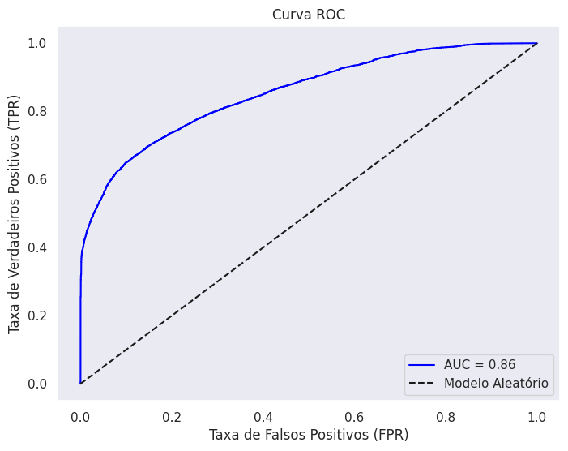

```python
# Probabilidades previstas (classe positiva)
y_prob = ridge_model.predict_proba(X_teste)[:, 1]

# Curva ROC
fpr, tpr, thresholds = roc_curve(y_teste, y_prob)
auc = roc_auc_score(y_teste, y_prob)

# Plot da Curva ROC
plt.figure(figsize=(8, 6))
plt.plot(fpr, tpr, label=f'AUC = {auc:.2f}', color='blue')
plt.plot([0, 1], [0, 1], 'k--', label='Modelo Aleatório')
plt.title('Curva ROC')
plt.xlabel('Taxa de Falsos Positivos (FPR)')
plt.ylabel('Taxa de Verdadeiros Positivos (TPR)')
plt.legend(loc='lower right')
plt.grid()
plt.show()
plt.tight_layout();
```

A Curva ROC (Receiver Operating Characteristic) é uma métrica de avaliação muito utilizada para modelos de classificação binária. Ela mede a capacidade do modelo em diferenciar entre as classes positiva e negativa.

O modelo apresenta um AUC = 0,86, o que indica uma boa capacidade de classificação. Isso significa que o modelo tem 86% de chance de classificar corretamente um cliente que poderá realizar ou não um cancelameto.

```python
# Impressão das métricas de classificação
y_pred = ridge_model.predict(X_teste)
print("\nRelatório de Classificação:\n", classification_report(y_teste, y_pred))
```

```
Relatório de Classificação:
               precision    recall  f1-score   support

           0       0.80      0.93      0.86     18792
           1       0.84      0.60      0.70     11055

    accuracy                           0.81     29847
   macro avg       0.82      0.77      0.78     29847
weighted avg       0.81      0.81      0.80     29847
```

O relatório indica que o modelo apresenta um bom desempenho na Classe 0 (reservas não canceladas). O modelo atingiu um recall de 93%, o que significa que ele consegue identificar corretamente 93% das reservas que realmente foram concluídas. Além disso, a precisão de 80% mostra que, entre todas as reservas classificadas como não canceladas, 80% foram corretamente identificadas.

Por outro lado, o desempenho na Classe 1 (reservas canceladas) foi moderado. O recall de 60% indica que o modelo conseguiu identificar 60% das reservas que realmente foram canceladas. No entanto, a precisão de 84% revela que, entre todas as reservas classificadas como canceladas, 84% estavam corretas, indicando uma quantidade considerável de falsos negativos.

A alta taxa de falsos negativos implica que muitas reservas que foram efetivamente canceladas não foram corretamente previstas, o que pode impactar a estratégia operacional do hotel, reduzindo a capacidade de antecipar cancelamentos. Por outro lado, a taxa de falsos positivos também merece atenção, pois algumas reservas que seriam concluídas podem ser incorretamente previstas como canceladas, o que pode levar a ações desnecessárias, como tentativa de retenção ou bloqueio indevido de quartos.

Em termos gerais, o modelo tem boa capacidade de prever reservas que serão mantidas, mas pode ser otimizado para melhorar a detecção de cancelamentos reais e reduzir falsos negativos, garantindo uma melhor alocação de recursos e minimizando impactos operacionais

```
Especificidade: 0.93
```

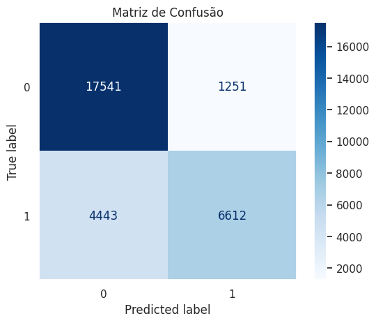

```python
# Matriz de confusão
cm = confusion_matrix(y_teste, y_pred)
tn, fp, fn, tp = cm.ravel()
specificity = tn / (tn + fp)
print(f"Especificidade: {specificity:.2f}")

disp = ConfusionMatrixDisplay(confusion_matrix=cm, display_labels=ridge_model.classes_)
disp.plot(cmap='Blues', values_format='d')
plt.title('Matriz de Confusão')
plt.grid(False)
plt.show()
```

Verdadeiros Negativos (TN) = 17.541: O modelo classificou corretamente 17.541 reservas como não canceladas, o que mostra que ele tem boa capacidade de identificar reservas que serão concluídas.

Verdadeiros Positivos (TP) = 6.612: O modelo conseguiu prever corretamente 6.612 casos em que as reservas foram canceladas, o que indica que há uma boa detecção de cancelamentos, mas ainda há espaço para melhoria.

Falsos Positivos (FP) = 1.251 O modelo classificou 1.251 reservas como canceladas, mas na realidade elas não foram canceladas. Isso pode levar a ações desnecessárias, como tentativas de retenção para clientes que não precisariam delas.

Falsos Negativos (FN) = 4.443 O modelo previu 4.443 reservas como não canceladas, mas elas foram canceladas. Esse é um número significativo, pois significa que muitos cancelamentos reais não foram detectados, o que pode afetar a gestão de disponibilidade do hotel e causar prejuízos operacionais.

Impacto dos Erros do Modelo Falsos Positivos (FP) Podem levar a ações desnecessárias, como tentativas de contato para retenção de clientes que não iriam cancelar a reserva.

Falsos Negativos (FN) Têm um impacto mais crítico, pois representam reservas canceladas que o modelo não previu, podendo gerar superlotação fictícia e problemas na gestão do hotel.

## 6. Conclusões

Nesta primeira versão do modelo, aplicamos uma abordagem básica de engenharia de atributos, focando na conversão de variáveis categóricas, análise de correlação e remoção de atributos menos relevantes. O modelo apresentou um desempenho satisfatório, especialmente na identificação de reservas que não serão canceladas.

Para versões futuras, podemos explorar engenharia de features mais avançada, como a criação de novas variáveis derivadas, interações entre atributos e técnicas de balanceamento da base para aprimorar a capacidade preditiva. Além disso, ajustes de hiperparâmetros e testes com modelos mais sofisticados podem contribuir para um melhor desempenho.

Esta versão representa um primeiro passo na modelagem preditiva do cancelamento de reservas. Com novas iterações e refinamentos, poderemos evoluir para um modelo mais robusto e eficaz, auxiliando de forma estratégica na gestão de demanda e retenção de clientes da rede hoteleira.